# chromosomix on a laptop

Time and memory of genome-wide analyses, run on the command line and in the app in three browsers, and six of them over a deep human map against the packages they reproduce, on the machine that renders this page

**Rendered** 6 November 2026, 08:55 UTC · **chromosomix** 0.21.0, release v0.21.0, at [`f2ac3bb1`](https://github.com/js2264/chromosomix/commit/f2ac3bb1f5b34ee369e543f413398b80a79f3235)  
**By** hand, on the machine below, as this page is published  
**On** Apple M1 Pro, 10 cores, 16 GB, Darwin 23.6.0 (arm64); Python 3.13.18, Quarto 1.10.19

The same analyses against the packages they reproduce: [the timings](https://chromosomix.app/timings/). Every run measured, on the command line and in each browser, with the machine, is a table to download under the results, and every step over the deep human map, with its memory weighed through it, two under its own.

How long does an analysis take in chromosomix, and how much memory does it need, when it is run over a whole genome on an ordinary laptop? This notebook answers that for 23 analyses on public data: Hi-C maps from 69 million to 1.08 billion contacts, a yeast Micro-C map down to 50 bp, and ATAC-seq tracks and sequence over the whole mouse genome. It ends on **a deep human map, start to finish**: six analyses one after the other over the 1.08 billion contacts, by six `chromosomix` commands and by one Python script running the packages they reproduce.

Each analysis is run on the command line and then in the app, in each of three browsers. **On the command line**, through `chromosomix`, the command-line form of the app’s Analysis panel: it runs the same code the browser runs, and as a process of its own its time and memory are measured by the operating system — the wall-clock time from start to finish, the CPU time, and the peak memory (the largest resident set the process reached). **In the app**, as a reader runs it (`notebooks/scripts/laptop.mjs`), in the three browser engines Playwright drives headless: Chromium, which Chrome and Edge are built on; Firefox; and WebKit, Safari’s engine. In each, the files the command names are dropped on the landing page, the task opened from the Analysis panel, every flag of the command set in its form, and **run** pressed. There the time is the app’s own, from the job’s dispatch to its result, as its console records it; the CPU time and the memory are the page’s, sampled from the press to the end. WebKit here is Playwright’s build of Safari’s engine rather than Safari, which cannot be run headless or driven so; on a Mac it is the nearest a script comes to it.

The block above says which machine this page was rendered on. The page published at https://chromosomix.app/laptop/ is rendered by hand, on a laptop, and committed as `notebooks/laptop.html`; `.github/workflows/notebooks.yml` renders it on a GitHub runner with every release too, but keeps that render as the run’s artifact and never publishes it. To measure your own, render it from the root of a clone, on a laptop that is plugged in and otherwise idle, with Node.js 22.12 or later, the app and the command line built from one commit, the three browsers of the Playwright `notebooks/viewers` pins — on Linux, `playwright install --with-deps`, for the system libraries Firefox and WebKit need — and an environment holding Quarto, Jupyter and the packages the page imports, which `notebooks/environment-laptop.yml` makes, named `open2c`:

```bash
npm ci && npm run build && npm run build:cli
npm ci --prefix notebooks/viewers && npx --prefix notebooks/viewers playwright install chromium firefox webkit
micromamba create -f notebooks/environment-laptop.yml
micromamba run -n open2c quarto render notebooks/laptop.qmd
```

`conda env create` and `mamba env create` read the same file, and `conda run -n open2c` renders as `micromamba run` does. The file holds pandas, matplotlib, numpy and pyfaidx, and for the last part alone the four packages its reference script runs — cooler, cooltools, coolpuppy and bioframe — at the versions `notebooks/requirements.txt` pins, the ones [`validation.qmd`](https://chromosomix.app/validation/) holds chromosomix to. Any environment holding them will do: the page checks, before it downloads or runs anything, that the Python it runs in has every one, and says which it lacks; it names the versions it found under *The machine*. A Chromium already installed can stand in for Playwright’s, named in `LAPTOP_CHROMIUM` or found under `PLAYWRIGHT_BROWSERS_PATH`; Firefox and WebKit are Playwright’s own builds. `LAPTOP_BROWSERS` names the browsers the app is run in, of `chromium,firefox,webkit`, all three unless it says, and the page is of those it names.

The page is one file and carries its table and its stamp inside it, so committing `notebooks/laptop.html` is all it takes to publish a render: the site’s build unpacks the two beside it.

```python
import hashlib
import json
import math
import os
import platform
import re
import shlex
import shutil
import subprocess
import sys
import tempfile
import time
from importlib.metadata import PackageNotFoundError, version as installed_version
from pathlib import Path
from statistics import geometric_mean

#: What the page imports, and what its last part's reference script (notebooks/scripts/cooltools_pipeline.py)
#: runs in this same Python: each looked for before anything is downloaded or run, so that one missing from
#: the environment stops the page now rather than hours in, at the deep map.
NEEDED = ['pandas', 'matplotlib', 'numpy', 'pyfaidx', 'cooler', 'cooltools', 'coolpuppy', 'bioframe', 'tables']
_missing = []
for _name in NEEDED:
    try:
        installed_version(_name)
    except PackageNotFoundError:
        _missing.append(_name)
# What coolpuppy's own command line, coolpup.py, needs beyond its package, for the deep map's last side: the
# h5sparse it imports calls `pkg_resources`, which setuptools shipped until 81.0.0; it writes its pileup with
# PyTables (`tables`, above); and its pool logs through multiprocessing-logging, whose 0.4.0 refuses to run where
# processes are spawned rather than forked, as on macOS, and whose 0.3.4 does not.
import importlib.util
if importlib.util.find_spec('pkg_resources') is None:
    _missing.append('setuptools 81.0.0 (or earlier), for its pkg_resources')
if sys.platform == 'darwin' and installed_version('multiprocessing-logging').startswith('0.4'):
    _missing.append('multiprocessing-logging 0.3.4, in place of the 0.4 installed')
if _missing:
    raise ModuleNotFoundError(
        f"{', '.join(_missing)} {'is' if len(_missing) == 1 else 'are'} not in the environment of {sys.executable}, "
        'which renders this page. Make one with `micromamba create -f notebooks/environment-laptop.yml` and render '
        'with `micromamba run -n open2c quarto render notebooks/laptop.qmd`. If that Python is not the '
        "environment's, a kernel named python3 installed outside it is answering for it: `jupyter kernelspec list`.")
if shutil.which('node') is None:
    raise FileNotFoundError('No `node` on the PATH: the page runs the command line and drives the browsers with '
                            'Node.js, 22.12 or later.')

import matplotlib.pyplot as plt
from matplotlib.patches import Patch
import pandas as pd
import pyfaidx

from download import download

REDO = False

HERE = Path.cwd().resolve()
REPO = HERE.parent if HERE.name == 'notebooks' else HERE
CLI = REPO / 'dist-cli' / 'chromosomix.mjs'
APP = REPO / 'dist'
DRIVER = REPO / 'notebooks' / 'scripts' / 'laptop.mjs'
WORK = REPO / 'notebooks' / 'work' / 'laptop'
DATA = WORK / 'data'
TIMINGS = WORK / 'timings.tsv'
DATA.mkdir(parents=True, exist_ok=True)
#: The browsers the app is run in, as Playwright names them and as the page does: LAPTOP_BROWSERS, else all three.
NAMES = {'chromium': 'Chromium', 'firefox': 'Firefox', 'webkit': 'WebKit'}
BROWSERS = [one.strip() for one in os.environ.get('LAPTOP_BROWSERS', ','.join(NAMES)).split(',') if one.strip()]
if not BROWSERS or set(BROWSERS) - set(NAMES) or len(set(BROWSERS)) < len(BROWSERS):
    raise ValueError(f"LAPTOP_BROWSERS is {os.environ.get('LAPTOP_BROWSERS')!r}: name each browser once, "
                     f"of {', '.join(NAMES)}.")
#: A Chromium to drive: LAPTOP_CHROMIUM, else the one under PLAYWRIGHT_BROWSERS_PATH, else Playwright's own.
#: Firefox and WebKit are always Playwright's own.
_browsers = os.environ.get('PLAYWRIGHT_BROWSERS_PATH', '')
EXECUTABLES = {'chromium': os.environ.get('LAPTOP_CHROMIUM') or (
    str(Path(_browsers) / 'chromium') if _browsers and (Path(_browsers) / 'chromium').is_file() else None)}

for built, how in ((CLI, 'npm run build:cli'), (APP / 'index.html', 'npm run build')):
    if not built.exists():
        raise FileNotFoundError(f'{built} is not there: run `{how}` at the repository root.')
VERSION = subprocess.run(['node', str(CLI), '--version'], capture_output=True, text=True).stdout.split('\n')[0]

# One build of one checkout in both places, as the parity holds them: the app names its build in its
# service worker's cache, `chromosomix-<version>-<commit>`; the command line, on `--version`. Two
# builds of two commits would be two programs timed against each other.
_cli = re.fullmatch(r'chromosomix (\S+)(?: \((\w+)\))?', VERSION)
_app = re.search(r'const CACHE = "([^"]*)"', (APP / 'sw.js').read_text()) if (APP / 'sw.js').exists() else None
if _cli is None or _app is None or _app[1] != '-'.join(filter(None, ('chromosomix', *_cli.groups()))):
    raise RuntimeError(f"dist/ is {_app[1] if _app else 'not the site build'} and dist-cli/ is {VERSION}: "
                       'run `npm run build && npm run build:cli` at the repository root, so both are this checkout.')
# Each browser launched once before any is timed, for its version and to know it is there.
VERSIONS = {}
for _browser in BROWSERS:
    _launched = subprocess.run(['node', str(DRIVER), '--version', _browser, *filter(None, [EXECUTABLES.get(_browser)])],
                               capture_output=True, text=True)
    if _launched.returncode:
        raise RuntimeError(f'No {NAMES[_browser]} to drive: install it with `npx --prefix notebooks/viewers playwright '
                           f'install {_browser}`, or leave it out of LAPTOP_BROWSERS.\n{_launched.stderr[-2000:]}')
    VERSIONS[_browser] = _launched.stdout.strip()
```

## The machine

```python
#: The versions notebooks/requirements.txt pins, the reference environment the validation runs in.
PINNED = dict(line.strip().split('==', 1) for line in (REPO / 'notebooks' / 'requirements.txt').read_text().splitlines()
              if '==' in line and not line.startswith('#'))


def found(name):
    """A package's version here, and the pin where it is not the one the reference environment holds."""
    here, pinned = installed_version(name), PINNED.get(name)
    return here if pinned in (None, here) else f'{here} (notebooks/requirements.txt pins {pinned})'


#: The machine, as every row of the tables carries it.
MACHINE = {
    'processor': R.machine['processor'],
    'cores': os.cpu_count(),
    'memory': f"{R.machine['memory_gb']:.0f} GB",
    'system': platform.platform(),
    'node': subprocess.run(['node', '--version'], capture_output=True, text=True).stdout.strip(),
    'chromosomix': VERSION.removeprefix('chromosomix '),
}
#: What the page ran in, said here and kept out of the tables: the Python and the environment it is in, by
#: name rather than by its path on this disk — the one the deep map's reference script runs in — and the
#: version of each package that script runs.
ENVIRONMENT = {'python': f'{platform.python_version()}, environment {Path(sys.prefix).name}',
               **{name: found(name) for name in ('cooler', 'cooltools', 'coolpuppy', 'bioframe')}}
pd.DataFrame([*MACHINE.items(), *ENVIRONMENT.items(), *((NAMES[one].lower(), VERSIONS[one]) for one in BROWSERS)],
             columns=['', 'this machine']).style.hide(axis='index')
```

|  | this machine |
| --- | --- |
| processor | Apple M1 Pro |
| cores | 10 |
| memory | 16 GB |
| system | macOS-14.6.1-arm64-arm-64bit-Mach-O |
| node | v24.14.0 |
| chromosomix | 0.21.0 (f2ac3bb1) |
| python | 3.13.18, environment open2c |
| cooler | 0.10.4 |
| cooltools | 0.7.1 |
| coolpuppy | 1.1.0 |
| bioframe | 0.8.0 |
| chromium | 141.0.7390.37 |
| firefox | 142.0.1 |
| webkit | 26.0 |

## The data

| Data | Source | Contacts | Size |
| --- | --- | --- | --- |
| Mouse Hi-C, mm10 | 4DN 4DNFIOZ1TRUS | 69 million | 0.7 GB |
| Human Hi-C, IMR-90, GRCh38 (Rao et al. 2014) | 4DN 4DNFIJTOIGOI | 1.08 billion | 8.3 GB |
| Yeast Micro-C (Costantino et al. 2020) | GEO GSE151553 | 51 million | 0.1 GB |
| Mouse ATAC-seq, two replicates | 4DN 4DNFIIY4QW2D, 4DNFITBRHVZE |  | 1.7 GB |
| Mouse genome sequence and RefSeq genes, mm10 | UCSC, as Illumina iGenomes distributes them |  | 2.9 GB |
| Human genome sequence, hg38, for the deep map’s GC content | UCSC, as Illumina iGenomes distributes it |  | 3.2 GB |

Every file is checked against its MD5 when it is downloaded. The mouse sequence is indexed beside itself (`mm10.fa.fai`) so that it is read by range; the human one is indexed by the last part, which alone reads it.

```python
FOURDN = 'https://4dn-open-data-public.s3.amazonaws.com/fourfront-webprod/wfoutput'
IGENOMES = 'https://ngi-igenomes.s3.amazonaws.com/igenomes/Mus_musculus/UCSC/mm10'
GEO = 'https://ftp.ncbi.nlm.nih.gov/geo/series'
FILES = {
    '4DNFIOZ1TRUS.mcool': (f'{FOURDN}/727b405d-c9f5-4b13-ae58-1dbf29d19a8f/4DNFIOZ1TRUS.mcool',
                           '503fea3d171e9c5c7f8a5403af73481e'),
    '4DNFIJTOIGOI.mcool': (f'{FOURDN}/b4939d95-4121-4f86-9cc8-29a34eb834ef/4DNFIJTOIGOI.mcool',
                           '659f9dc7613650494aa5ed4138e2e17e'),
    'GSE151553_A364_merged.mcool': (f'{GEO}/GSE151nnn/GSE151553/suppl/GSE151553_A364_merged.mcool',
                                    '319a04a8d7e41d9eb88e2378ea3ea373'),
    '4DNFIIY4QW2D.bw': (f'{FOURDN}/7fb6d419-a8de-4bc8-9c17-f68f814496a2/4DNFIIY4QW2D.bw',
                        '9f8a3a413f54129a689548a93584cdf4'),
    '4DNFITBRHVZE.bw': (f'{FOURDN}/e567a80e-c7d2-41ff-b12d-67047906c076/4DNFITBRHVZE.bw',
                        '99c928ea99ee1a2a7ec7091260f1e4be'),
    'mm10.fa': (f'{IGENOMES}/Sequence/WholeGenomeFasta/genome.fa', '34d90c586dc92f5c3e8df3ed24530f4f'),
    'mm10.genes.gtf': (f'{IGENOMES}/Annotation/Genes/genes.gtf', '543ec24bb11a4ff0cf5aa4f695320b82'),
    'hg38.fa': ('https://ngi-igenomes.s3.amazonaws.com/igenomes/Homo_sapiens/UCSC/hg38/Sequence/WholeGenomeFasta/'
                'genome.fa', '9ce261c4aaf4b6092888ef298d190da2'),
}
VALIDATION_DATA = REPO / 'notebooks' / 'work' / 'validation' / 'data'


def md5(path):
    digest = hashlib.md5()
    with open(path, 'rb') as handle:
        for block in iter(lambda: handle.read(1 << 22), b''):
            digest.update(block)
    return digest.hexdigest()


def fetch(name, url, expected):
    path = DATA / name
    if path.exists():
        return
    if (VALIDATION_DATA / name).exists():
        path.symlink_to(VALIDATION_DATA / name)
        return
    print('downloading', url)
    part = download(url, path.with_name(name + '.part'))  # asked again when its server fails
    if md5(part) != expected:
        part.unlink()
        raise ValueError(f'{url} did not download as published: its MD5 is not {expected}.')
    part.rename(path)


for name, (url, expected) in FILES.items():
    fetch(name, url, expected)
pyfaidx.Faidx(str(DATA / 'mm10.fa')).close()

pd.DataFrame([{'file': name, 'GB': round((DATA / name).stat().st_size / 1e9, 2)} for name in FILES]) \
    .style.hide(axis='index').format(precision=2)
```

| file | GB |
| --- | --- |
| 4DNFIOZ1TRUS.mcool | 0.69 |
| 4DNFIJTOIGOI.mcool | 8.31 |
| GSE151553_A364_merged.mcool | 0.12 |
| 4DNFIIY4QW2D.bw | 0.96 |
| 4DNFITBRHVZE.bw | 0.74 |
| mm10.fa | 2.78 |
| mm10.genes.gtf | 0.09 |
| hg38.fa | 3.16 |

## The analyses

Each analysis is one command, run from `notebooks/work/laptop/` with its output in `out/<name>/`. Two of them read another’s output: the pileup (APA) is over the loops chromosight called, and the overlap is of the peaks called on the ATAC-seq replicates against the RefSeq transcripts. Parameters are the app’s defaults, except where the validation notebook uses others for the same analysis.

```python
MOUSE, HUMAN, YEAST = 'data/4DNFIOZ1TRUS.mcool', 'data/4DNFIJTOIGOI.mcool', 'data/GSE151553_A364_merged.mcool'
ATAC1, ATAC2, MM10, GENES = 'data/4DNFIIY4QW2D.bw', 'data/4DNFITBRHVZE.bw', 'data/mm10.fa', 'data/mm10.genes.gtf'
LOOPS = 'out/chromosight/4DNFIOZ1TRUS_10000.chromosight.chromosight-patterns.bedpe'
PEAKS = 'out/peaks/4DNFIIY4QW2D.peaks.peaks-data_4DNFIIY4QW2D_bw-data_4DNFITBRHVZE_bw.bed'


def at(path, bp):
    return f'{path}::/resolutions/{bp}'


# name, data, analysis, resolution, and the command after `chromosomix`
TASKS = [
    ('coverage', 'Mouse Hi-C', 'Coverage, balanced', '10 kb',
     ['coverage', at(MOUSE, 10_000), '--balance']),
    ('expected', 'Mouse Hi-C', 'P(s)', '10 kb',
     ['expected', at(MOUSE, 10_000), '--quantity', 'expected', '--scope', 'file']),
    ('insulation', 'Mouse Hi-C', 'Insulation, 100 kb window, boundaries', '10 kb',
     ['insulation', at(MOUSE, 10_000), '--window', '10']),
    ('di', 'Mouse Hi-C', 'Directionality index, 2 Mb window, borders', '50 kb',
     ['di', at(MOUSE, 50_000), '--window', '40']),
    ('compartments', 'Mouse Hi-C', 'Compartments (E1) and saddle', '100 kb',
     ['compartments', at(MOUSE, 100_000)]),
    ('loops', 'Mouse Hi-C', 'Loop calling (cooltools dots), to 10 Mb', '10 kb',
     ['loops', at(MOUSE, 10_000)]),
    ('chromosight', 'Mouse Hi-C', 'Loop detection (chromosight), to 2 Mb', '10 kb',
     ['chromosight', at(MOUSE, 10_000), '--pattern', 'loops']),
    ('apa', 'Mouse Hi-C', "APA over chromosight's loops", '10 kb',
     ['apa', at(MOUSE, 10_000), '--pairs', LOOPS]),
    ('model', 'Mouse Hi-C', '3D model of the genome (pastis-NB)', '1 Mb',
     ['reconstruct3d', at(MOUSE, 1_000_000), '--method', 'nb', '--alpha', '3']),

    ('human-coverage', 'Human Hi-C', 'Coverage, balanced', '10 kb',
     ['coverage', at(HUMAN, 10_000), '--balance']),
    ('human-expected', 'Human Hi-C', 'P(s)', '10 kb',
     ['expected', at(HUMAN, 10_000), '--quantity', 'expected', '--scope', 'file']),
    ('human-insulation', 'Human Hi-C', 'Insulation, 100 kb window, boundaries', '10 kb',
     ['insulation', at(HUMAN, 10_000), '--window', '10']),
    ('human-compartments', 'Human Hi-C', 'Compartments (E1) and saddle', '100 kb',
     ['compartments', at(HUMAN, 100_000)]),
    ('human-loops', 'Human Hi-C', 'Loop calling (cooltools dots), to 10 Mb', '10 kb',
     ['loops', at(HUMAN, 10_000)]),

    ('yeast-expected', 'Yeast Micro-C', 'P(s)', '50 bp',
     ['expected', at(YEAST, 50), '--quantity', 'expected', '--scope', 'file']),
    ('yeast-chromosight', 'Yeast Micro-C', 'Loop detection (chromosight)', '800 bp',
     ['chromosight', at(YEAST, 800), '--pattern', 'loops']),
    ('yeast-model', 'Yeast Micro-C', '3D model of the genome (pastis-NB)', '12.8 kb',
     ['reconstruct3d', at(YEAST, 12_800), '--method', 'nb', '--alpha', '3']),

    ('peaks', 'Mouse ATAC-seq, mm10', 'Peak calling with IDR, two replicates', '1 bp',
     ['peaks', '--signal', ATAC1, '--replicate', ATAC2, '--width', '150', '--times', '3', '--minWidth', '75',
      '--truncate', '100000', '--idr', '0.05']),
    ('overlap', 'Mouse ATAC-seq, mm10', 'Overlap of the peaks with transcripts, 1,000 shuffles', '1 bp',
     ['overlap', '--sequence', MM10, '--features', PEAKS, '--features', GENES, '--a', PEAKS, '--b', GENES,
      '--shuffle', '--iterations', '1000', '--seed', '1']),
    ('metaplot', 'Mouse ATAC-seq, mm10', 'Metaplot at every RefSeq TSS, ±2 kb', '50 bp',
     ['metaplot', '--tracks', ATAC1, '--features', GENES, '--mode', 'reference', '--at', 'start', '--flank',
      '2000', '--step', '50', '--band', 'none']),
    ('trackcorr', 'Mouse ATAC-seq, mm10', 'Correlation of the two replicates (Spearman)', '1 kb',
     ['trackcorr', '--tracks', f'{ATAC1},{ATAC2}', '--binsize', '1000', '--method', 'spearman']),
    ('composition', 'Mouse ATAC-seq, mm10', 'Base composition: GC, skews', '10 kb',
     ['composition', '--sequence', MM10, '--resolution', '10000']),
    ('motif', 'Mouse ATAC-seq, mm10', 'Motif search, CTCF core, ≤ 1 mismatch', '1 bp',
     ['motif', '--sequence', MM10, '--pattern', 'CCGCGNGGNGGCAG', '--mismatches', '1']),
]
```

In the app, each command becomes what a reader does to run it (`session` below). A command on a map opens it as a workspace names it — the file at the command’s resolution, balanced, its whole genome on screen — and the file is dropped on the landing page with the other the command names, a set of loops, as a track beside it; a command on tracks or sequence alone drops its files alone, a FASTA with its index. The task is opened from the Analysis panel by the title `chromosomix tasks` gives it, and every flag of the command is set in its form, the parameter it names: a number typed, a choice chosen, a switch turned on, a file chosen by its name among those open and the tracks ticked. `--features` and `--sequence` are the exception: they open the feature sets and the reference a task reads, and the form chooses the one open for itself, or the two `--a` and `--b` name.

```python
#: Every task's title in the Analysis panel, its parameters and their defaults, as `chromosomix tasks`
#: lists them: a parameter listed with none is one the form answers from what is open.
_tasks = subprocess.run(['node', str(CLI), 'tasks'], capture_output=True, text=True).stdout
TITLES = dict(re.findall(r'^(\w+)\n {4}(\S.*)$', _tasks, re.M))
PARAMETERS, DEFAULTS = {}, {}
for _block in _tasks.split('\n\n'):
    _id = _block.strip().split('\n')[0]
    PARAMETERS[_id] = set(re.findall(r'^ {6}--(\w+)\b', _block, re.M))
    DEFAULTS[_id] = {key: value.strip('"') for key, value in re.findall(r'^ {6}--(\w+) \(default (.*?)\)  ', _block, re.M)}

#: The flags that open what a task reads rather than set its form.
OPENED = {'features', 'sequence'}


def stem(path):
    """A file as the app names it once it is open: its name, up to its first dot."""
    return Path(path).name.split('.')[0]


def beside_the_map(number, path):
    """A file a command reads beside its map, as a workspace names it: a set of loops, on the map."""
    if not path.endswith('.bedpe'):
        raise ValueError(f'{path}: a BEDPE of loops is the one file opened beside a map here.')
    return {'id': f'pairs{number}', 'card': 'overlay', 'kind': 'pairs', 'label': stem(path),
            'source': {'kind': 'local', 'name': Path(path).name}, 'visible': True,
            'placement': {'bottom': True, 'right': False}}


def session(name, args):
    """What the app is handed for one command: the files it names, the workspace that frames its map,
    the task's title and every setting of its form."""
    task, *words = args
    the_map, files, form = None, [], []
    while words:
        word = words.pop(0)
        if not word.startswith('--'):
            the_map = word
            continue
        key = word[2:]
        value = words.pop(0) if words and not words[0].startswith('--') else None
        paths = [] if value is None else [one for one in value.split(',') if one.startswith(('data/', 'out/'))]
        if value is None:
            form.append({'key': key, 'on': True})
        elif not paths:
            form.append({'key': key, 'value': value})
        else:
            files += [one for one in paths if one not in files]
            if key == 'tracks':
                form.append({'key': key, 'ticks': [stem(one) for one in paths]})
            elif key not in OPENED:
                form.append({'key': key, 'option': stem(value)})
    files += [f'{one}.fai' for one in files if one.endswith('.fa')]
    plan = {'name': name, 'task': TITLES[task], 'set': form, 'files': files}
    if the_map is not None:
        path, group = the_map.split('::')
        plan['files'] = [path, *files]
        plan['workspace'] = {'kind': 'chromosomix.workspace', 'version': 1, 'active': 0, 'tabs': [{
            'version': 1, 'state': {'uri': f'{Path(path).name}::{group}', 'view': 'whole', 'balance': True},
            'tracks': [beside_the_map(number, one) for number, one in enumerate(files)]}]}
    return plan
```

Each analysis is run on the command line and then in each browser, one after another, and the first of them to read a file would find it on disk where the others find it in the system’s memory: an 8.3 GB map read from disk took the run that read it first more than twice as long. So before each run, on the command line or in a browser, every file the command names is read through once, and every run starts from files the system holds in memory, as a reader’s do once they have opened them.

On the command line, each command runs as a process of its own, and `os.wait4` returns what the system counted of it: its CPU time, user and system, and its peak resident memory (`ru_maxrss`, which macOS gives in bytes and Linux in kilobytes).

In the app, each command runs in each browser in turn, a browser of its own, launched for it and closed after it, so that nothing an earlier run read or drew is in what this one holds. Once the files are open and the form is set, the page is left until the map is drawn, the app has measured which of its sequences are circles, and the browser is idle — what the app starts by itself once a map is open is over before the run — and then **run** is pressed. A page waiting on the disk spends no CPU, and the measure of the circles reads at a few percent of a core, so neither is told apart from idle by the CPU: the app’s own word that it has drawn a map, and that it has measured its circles, is waited for. Until the console records the run’s end, the browser’s processes are sampled five times a second, the same way in the three: their CPU times and resident sets as the operating system counts them, from `/proc` on Linux and `ps` on macOS. The page’s are the processes that render pages — Chromium’s renderers, Firefox’s web content processes, WebKit’s web processes — whose threads are its workers, where the app computes and holds what it reads; its CPU time is what they spent between the press and the end, and its peak memory their largest resident set — sampled, so a peak shorter than a fifth of a second can be missed, where `ru_maxrss` cannot miss one. The browser’s other processes — the browser itself, which reads the dropped files for the page, and its GPU, network and storage processes — are counted apart, as `all_cpu_s` and `all_peak_mb` in the table under the results, the page’s included. Each draws as it does headless: Chromium draws WebGL in software (SwiftShader) and composites the page in software too; Firefox and WebKit draw as Playwright launches them, Firefox allowed WebGL whatever its blocklist says of the machine’s graphics. A reader’s browser has a GPU for all of it. Each run leaves what it was handed, what it measured and a picture of the page at its end in `notebooks/work/laptop/app/<browser>/<name>/`.

```python
def on_the_command_line(name, args):
    """One command: its wall-clock and CPU seconds, and its peak memory in MB."""
    out = WORK / 'out' / name
    shutil.rmtree(out, ignore_errors=True)
    out.mkdir(parents=True)
    with tempfile.TemporaryFile() as err:
        start = time.perf_counter()
        process = subprocess.Popen(['node', str(CLI), *args, '--out', f'out/{name}', '--quiet'], cwd=WORK,
                                   stdout=subprocess.DEVNULL, stderr=err)
        _, status, usage = os.wait4(process.pid, 0)
        wall = time.perf_counter() - start
        if os.waitstatus_to_exitcode(status):
            err.seek(0)
            raise RuntimeError(f'chromosomix {" ".join(args)} failed:\n{err.read().decode()[-3000:]}')
    peak = usage.ru_maxrss / (2**20 if sys.platform == 'darwin' else 2**10)
    return {'wall_s': wall, 'cpu_s': usage.ru_utime + usage.ru_stime, 'peak_mb': peak}


#: What a run in the app measures beside the command line's three: the page before the run, the opening
#: of its files, and every process of the browser.
APP_ONLY = ['rest_mb', 'open_s', 'all_cpu_s', 'all_peak_mb']


def in_the_app(name, args, browser):
    """One command run in the app in one browser: its time, the page's CPU seconds and peak memory in MB,
    all of the browser's, and the line its console wrote — or, where it did not finish, why."""
    folder = WORK / 'app' / browser / name
    folder.mkdir(parents=True, exist_ok=True)
    plan = {**session(name, args), 'browser': browser, 'app': str(APP), 'data': str(WORK), 'out': str(folder),
            'executablePath': EXECUTABLES.get(browser)}
    (folder / 'plan.json').write_text(json.dumps(plan, indent=1))
    (folder / 'result.json').unlink(missing_ok=True)
    driven = subprocess.run(['node', str(DRIVER), str(folder / 'plan.json'), str(folder / 'result.json')],
                            capture_output=True, text=True)
    if not (folder / 'result.json').exists():
        raise RuntimeError(f'{DRIVER.name} wrote no result for {name} in {NAMES[browser]}:\n{driven.stderr[-3000:]}')
    result = json.loads((folder / 'result.json').read_text())
    ran = result['status'] == 'ok'
    measured = {key: result[key] if ran else math.nan for key in ['wall_s', 'cpu_s', 'peak_mb', *APP_ONLY]}
    return {**measured, 'line': result.get('line', ''), 'error': '' if ran else result.get('error', 'failed')}


#: Where each analysis is run, in order — the command line, then each browser — and what each is: Node's
#: version on the command line, the browser's in the app.
VENUES = ['command line', *(NAMES[one] for one in BROWSERS)]
APPS = VENUES[1:]
PROGRAMS = {'command line': MACHINE['node'], **{NAMES[one]: VERSIONS[one] for one in BROWSERS}}


def kept():
    """What an earlier render of this same build measured, run by run: on the command line in this same
    Node, and in each browser asked for at the version it is now. A run the app did not finish is run
    again."""
    if REDO or not TIMINGS.exists():
        return []
    done = pd.read_csv(TIMINGS, sep='\t', dtype={'version': str})
    if not {'venue', 'version', 'error'} <= set(done.columns):
        return []
    done = done.fillna({'line': '', 'error': '', 'version': ''})
    same = (done['chromosomix'] == MACHINE['chromosomix']) & (done['version'] == done['venue'].map(PROGRAMS))
    return done[same & (done['error'] == '') & done['wall_s'].notna()].to_dict('records')


def save(rows):
    pd.DataFrame(rows).to_csv(TIMINGS, sep='\t', index=False)


def warm(name, args):
    """Read through every file a command names, so that no run pays alone for reading them from disk."""
    for path in session(name, args)['files']:
        with open(WORK / path, 'rb') as handle:
            while handle.read(1 << 24):
                pass


# Each command on the command line and then in each browser — the pileup's loops and the overlap's peaks
# are the command line's, so every venue reads the same files — and each run saved as soon as it is
# measured, one row each.
rows = kept()
for name, data, analysis, resolution, args in TASKS:
    task = {'name': name, 'data': data, 'analysis': analysis, 'resolution': resolution}
    done = {row['venue'] for row in rows if row['name'] == name}
    for venue, browser in zip(VENUES, [None, *BROWSERS]):
        if venue in done:
            continue
        warm(name, args)
        measured = on_the_command_line(name, args) if browser is None else in_the_app(name, args, browser)
        rows.append({**task, 'venue': venue, 'version': PROGRAMS[venue], **measured,
                     'command': 'chromosomix ' + ' '.join(args), **MACHINE})
        save(rows)

#: Every run, one row each, in the order of TASKS and of VENUES; and each analysis once, with its labels.
ORDER = [task[0] for task in TASKS]
times = pd.DataFrame(rows).fillna({'line': '', 'error': ''})
for column in APP_ONLY:
    times[column] = times[column] if column in times else math.nan
times = times.sort_values(['name', 'venue'], key=lambda column: column.map(
    {'name': ORDER, 'venue': VENUES}[column.name].index)).reset_index(drop=True)
times['added_mb'] = times['peak_mb'] - times['rest_mb']
TASK = times.drop_duplicates('name').set_index('name').loc[ORDER, ['data', 'analysis', 'resolution', 'command']]
FAILED = times[times['error'] != '']


def wide(column, venues=VENUES):
    """One measure of every analysis, a column for each venue."""
    return times.pivot(index='name', columns='venue', values=column).reindex(index=ORDER, columns=venues)
```

## Results

Every run measured, one row each — on the command line or in a browser — with its command, the app’s line for it, the browser’s version and the machine: `timings.tsv`.

```python
def duration(seconds):
    if math.isnan(seconds):
        return '—'
    return f'{seconds:.1f} s' if seconds < 60 else f'{seconds / 60:.1f} min'


def megabytes(mb):
    return '—' if math.isnan(mb) else f'{mb:,.0f}'


# A time kept on one line in a cell: `3.7 min` broken after its number reads as two figures.
unbroken = lambda seconds: duration(seconds).replace(' ', '\N{NO-BREAK SPACE}')


def measure(heading, column, shown, added=False):
    """A table of one measure: each analysis, and a column for each venue under the measure's heading —
    and, for the memory, beside the whole peak, what the run added to the page in each browser."""
    table = pd.DataFrame({('', key): TASK[key].values for key in ['data', 'analysis', 'resolution']})
    for venue, values in wide(column).items():
        table[(heading, venue)] = values.map(shown).values
    if added:
        for venue, values in wide('added_mb', APPS).items():
            table[('added by the run (MB)', venue)] = values.map(shown).values
    table.columns = pd.MultiIndex.from_tuples(table.columns)
    return table.style.hide(axis='index')
```

**Wall-clock time**

```python
measure('wall-clock time', 'wall_s', unbroken)
```

| data | analysis | resolution | wall-clock time command line | wall-clock time Chromium | wall-clock time Firefox | wall-clock time WebKit |
| --- | --- | --- | --- | --- | --- | --- |
| Mouse Hi-C | Coverage, balanced | 10 kb | 3.6 s | 3.2 s | 9.3 s | 2.8 s |
| Mouse Hi-C | P(s) | 10 kb | 3.3 s | 3.2 s | 9.2 s | 2.7 s |
| Mouse Hi-C | Insulation, 100 kb window, boundaries | 10 kb | 4.8 s | 4.2 s | 14.3 s | 4.5 s |
| Mouse Hi-C | Directionality index, 2 Mb window, borders | 50 kb | 2.4 s | 2.2 s | 7.1 s | 2.2 s |
| Mouse Hi-C | Compartments (E1) and saddle | 100 kb | 4.4 s | 4.0 s | 7.9 s | 3.7 s |
| Mouse Hi-C | Loop calling (cooltools dots), to 10 Mb | 10 kb | 27.9 s | 28.9 s | 57.7 s | 32.7 s |
| Mouse Hi-C | Loop detection (chromosight), to 2 Mb | 10 kb | 27.0 s | 28.1 s | 48.9 s | 27.8 s |
| Mouse Hi-C | APA over chromosight's loops | 10 kb | 5.8 s | 5.9 s | 19.8 s | 6.0 s |
| Mouse Hi-C | 3D model of the genome (pastis-NB) | 1 Mb | 45.9 s | 12.5 s | 24.6 s | 9.1 s |
| Human Hi-C | Coverage, balanced | 10 kb | 17.9 s | 19.8 s | 1.4 min | 17.4 s |
| Human Hi-C | P(s) | 10 kb | 17.3 s | 19.1 s | 1.4 min | 16.3 s |
| Human Hi-C | Insulation, 100 kb window, boundaries | 10 kb | 17.8 s | 19.5 s | 1.5 min | 19.5 s |
| Human Hi-C | Compartments (E1) and saddle | 100 kb | 9.6 s | 10.0 s | 37.1 s | 9.9 s |
| Human Hi-C | Loop calling (cooltools dots), to 10 Mb | 10 kb | 53.6 s | 56.7 s | 2.5 min | 1.1 min |
| Yeast Micro-C | P(s) | 50 bp | 2.2 s | 2.1 s | 6.1 s | 1.8 s |
| Yeast Micro-C | Loop detection (chromosight) | 800 bp | 4.8 s | 5.0 s | 8.0 s | 5.2 s |
| Yeast Micro-C | 3D model of the genome (pastis-NB) | 12.8 kb | 6.2 s | 2.0 s | 3.2 s | 1.7 s |
| Mouse ATAC-seq, mm10 | Peak calling with IDR, two replicates | 1 bp | 1.7 min | 2.0 min | 21.0 min | 2.1 min |
| Mouse ATAC-seq, mm10 | Overlap of the peaks with transcripts, 1,000 shuffles | 1 bp | 7.2 s | 6.2 s | 8.3 s | 7.6 s |
| Mouse ATAC-seq, mm10 | Metaplot at every RefSeq TSS, ±2 kb | 50 bp | 5.1 s | 7.6 s | 17.6 s | 9.6 s |
| Mouse ATAC-seq, mm10 | Correlation of the two replicates (Spearman) | 1 kb | 17.5 s | 22.2 s | 1.3 min | 18.0 s |
| Mouse ATAC-seq, mm10 | Base composition: GC, skews | 10 kb | 4.1 s | 10.7 s | 10.2 s | 7.3 s |
| Mouse ATAC-seq, mm10 | Motif search, CTCF core, ≤ 1 mismatch | 1 bp | 40.9 s | 51.4 s | 1.5 min | 49.2 s |

**CPU time**

```python
measure('CPU time', 'cpu_s', unbroken)
```

| data | analysis | resolution | CPU time command line | CPU time Chromium | CPU time Firefox | CPU time WebKit |
| --- | --- | --- | --- | --- | --- | --- |
| Mouse Hi-C | Coverage, balanced | 10 kb | 4.1 s | 4.2 s | 11.4 s | 3.6 s |
| Mouse Hi-C | P(s) | 10 kb | 3.7 s | 4.3 s | 11.3 s | 3.7 s |
| Mouse Hi-C | Insulation, 100 kb window, boundaries | 10 kb | 5.8 s | 5.7 s | 17.0 s | 6.1 s |
| Mouse Hi-C | Directionality index, 2 Mb window, borders | 50 kb | 2.9 s | 3.1 s | 8.7 s | 3.3 s |
| Mouse Hi-C | Compartments (E1) and saddle | 100 kb | 5.8 s | 7.1 s | 11.4 s | 6.3 s |
| Mouse Hi-C | Loop calling (cooltools dots), to 10 Mb | 10 kb | 30.7 s | 38.5 s | 1.2 min | 39.6 s |
| Mouse Hi-C | Loop detection (chromosight), to 2 Mb | 10 kb | 28.9 s | 31.8 s | 53.5 s | 30.8 s |
| Mouse Hi-C | APA over chromosight's loops | 10 kb | 6.8 s | 7.8 s | 23.1 s | 7.8 s |
| Mouse Hi-C | 3D model of the genome (pastis-NB) | 1 Mb | 46.6 s | 1.1 min | 1.6 min | 36.0 s |
| Human Hi-C | Coverage, balanced | 10 kb | 20.1 s | 24.5 s | 1.6 min | 19.7 s |
| Human Hi-C | P(s) | 10 kb | 19.2 s | 23.7 s | 1.6 min | 18.4 s |
| Human Hi-C | Insulation, 100 kb window, boundaries | 10 kb | 20.1 s | 23.1 s | 1.7 min | 22.2 s |
| Human Hi-C | Compartments (E1) and saddle | 100 kb | 11.5 s | 14.2 s | 42.0 s | 13.1 s |
| Human Hi-C | Loop calling (cooltools dots), to 10 Mb | 10 kb | 58.3 s | 1.2 min | 2.9 min | 1.4 min |
| Yeast Micro-C | P(s) | 50 bp | 2.4 s | 2.8 s | 7.3 s | 2.6 s |
| Yeast Micro-C | Loop detection (chromosight) | 800 bp | 5.6 s | 9.3 s | 11.2 s | 7.1 s |
| Yeast Micro-C | 3D model of the genome (pastis-NB) | 12.8 kb | 6.4 s | 9.3 s | 11.5 s | 6.3 s |
| Mouse ATAC-seq, mm10 | Peak calling with IDR, two replicates | 1 bp | 1.8 min | 2.5 min | 23.4 min | 2.3 min |
| Mouse ATAC-seq, mm10 | Overlap of the peaks with transcripts, 1,000 shuffles | 1 bp | 7.4 s | 7.9 s | 10.8 s | 8.8 s |
| Mouse ATAC-seq, mm10 | Metaplot at every RefSeq TSS, ±2 kb | 50 bp | 6.0 s | 7.9 s | 15.7 s | 10.0 s |
| Mouse ATAC-seq, mm10 | Correlation of the two replicates (Spearman) | 1 kb | 19.9 s | 22.6 s | 1.3 min | 19.2 s |
| Mouse ATAC-seq, mm10 | Base composition: GC, skews | 10 kb | 4.6 s | 11.7 s | 11.6 s | 8.1 s |
| Mouse ATAC-seq, mm10 | Motif search, CTCF core, ≤ 1 mismatch | 1 bp | 41.1 s | 58.5 s | 1.6 min | 52.3 s |

**Memory**

```python
measure('peak memory (MB)', 'peak_mb', megabytes, added=True)
```

| data | analysis | resolution | peak memory (MB) command line | peak memory (MB) Chromium | peak memory (MB) Firefox | peak memory (MB) WebKit | added by the run (MB) Chromium | added by the run (MB) Firefox | added by the run (MB) WebKit |
| --- | --- | --- | --- | --- | --- | --- | --- | --- | --- |
| Mouse Hi-C | Coverage, balanced | 10 kb | 473 | 1,098 | 1,291 | 1,100 | 171 | 337 | 206 |
| Mouse Hi-C | P(s) | 10 kb | 324 | 1,086 | 1,278 | 1,105 | 158 | 323 | 228 |
| Mouse Hi-C | Insulation, 100 kb window, boundaries | 10 kb | 391 | 1,238 | 1,239 | 1,256 | 311 | 284 | 385 |
| Mouse Hi-C | Directionality index, 2 Mb window, borders | 50 kb | 261 | 1,128 | 1,169 | 1,089 | 200 | 214 | 207 |
| Mouse Hi-C | Compartments (E1) and saddle | 100 kb | 455 | 1,376 | 1,471 | 1,364 | 451 | 518 | 518 |
| Mouse Hi-C | Loop calling (cooltools dots), to 10 Mb | 10 kb | 846 | 1,356 | 1,491 | 1,988 | 438 | 538 | 1,111 |
| Mouse Hi-C | Loop detection (chromosight), to 2 Mb | 10 kb | 512 | 1,313 | 1,363 | 2,168 | 385 | 410 | 1,292 |
| Mouse Hi-C | APA over chromosight's loops | 10 kb | 285 | 1,288 | 1,249 | 1,307 | 351 | 288 | 419 |
| Mouse Hi-C | 3D model of the genome (pastis-NB) | 1 Mb | 390 | 1,110 | 1,081 | 1,675 | 550 | 757 | 1,075 |
| Human Hi-C | Coverage, balanced | 10 kb | 584 | 1,215 | 1,344 | 2,527 | 201 | 345 | 1,513 |
| Human Hi-C | P(s) | 10 kb | 503 | 1,231 | 1,302 | 1,843 | 216 | 352 | 814 |
| Human Hi-C | Insulation, 100 kb window, boundaries | 10 kb | 618 | 1,231 | 1,355 | 2,612 | 218 | 342 | 1,587 |
| Human Hi-C | Compartments (E1) and saddle | 100 kb | 729 | 1,513 | 1,647 | 2,525 | 499 | 626 | 1,493 |
| Human Hi-C | Loop calling (cooltools dots), to 10 Mb | 10 kb | 2,078 | 2,138 | 2,102 | 2,625 | 1,128 | 1,114 | 1,600 |
| Yeast Micro-C | P(s) | 50 bp | 300 | 1,541 | 1,558 | 1,312 | 137 | 211 | 219 |
| Yeast Micro-C | Loop detection (chromosight) | 800 bp | 434 | 1,184 | 1,381 | 2,488 | 430 | 643 | 1,708 |
| Yeast Micro-C | 3D model of the genome (pastis-NB) | 12.8 kb | 243 | 677 | 667 | 848 | 257 | 272 | 498 |
| Mouse ATAC-seq, mm10 | Peak calling with IDR, two replicates | 1 bp | 676 | 927 | 1,018 | 1,466 | 546 | 638 | 1,259 |
| Mouse ATAC-seq, mm10 | Overlap of the peaks with transcripts, 1,000 shuffles | 1 bp | 530 | 883 | 505 | 1,123 | 95 | 28 | 12 |
| Mouse ATAC-seq, mm10 | Metaplot at every RefSeq TSS, ±2 kb | 50 bp | 809 | 665 | 608 | 1,760 | 99 | 188 | 481 |
| Mouse ATAC-seq, mm10 | Correlation of the two replicates (Spearman) | 1 kb | 841 | 977 | 701 | 1,077 | 590 | 327 | 872 |
| Mouse ATAC-seq, mm10 | Base composition: GC, skews | 10 kb | 504 | 475 | 676 | 588 | 99 | 365 | 402 |
| Mouse ATAC-seq, mm10 | Motif search, CTCF core, ≤ 1 mismatch | 1 bp | 247 | 553 | 517 | 679 | 169 | 174 | 493 |

```python
def listing(words):
    """`a`, `a and b`, `a, b and c`."""
    words = [str(word) for word in words]
    return ' and '.join(words) if len(words) < 3 else f"{', '.join(words[:-1])} and {words[-1]}"


def where(venue):
    return 'on the command line' if venue == 'command line' else f'in {venue}'


def extremes(venue):
    """Of one venue's runs: how many took under a minute, the slowest, and the one that held the most —
    none, where none finished."""
    ran = times[(times['venue'] == venue) & times['wall_s'].notna()]
    if ran.empty:
        return 0, None, None
    return int((ran['wall_s'] < 60).sum()), ran.loc[ran['wall_s'].idxmax()], ran.loc[ran['peak_mb'].idxmax()]


def ratios(series, of):
    """A set of ratios, analysis by analysis, in words."""
    if series.empty:
        return 'no analysis finished in both to compare'
    return f'{series.median():.1f} times {of} at the median, from {series.min():.1f} to {series.max():.1f} times'


def on_average(venue):
    """A browser's CPU time and peak memory over the command line's, as geometric means of its analyses."""
    cpu, memory = ((measured[venue] / measured['command line']).dropna() for measured in (CPU, PEAK))
    if cpu.empty:
        return f'{where(venue)}, no analysis finished in both to compare'
    return (f"{where(venue)}, {geometric_mean(cpu):.1f} times the command line's CPU time and "
            f"{geometric_mean(memory):.1f} times its peak memory")


EXTREMES = {venue: extremes(venue) for venue in VENUES}
WALL, CPU, PEAK = wide('wall_s'), wide('cpu_s'), wide('peak_mb')
#: Each browser's time over the command line's, analysis by analysis; and, for each browser after the
#: first, its time and its memory over the first's.
AGAINST_THE_LINE = {venue: (WALL[venue] / WALL['command line']).dropna() for venue in APPS}
FIRST, OTHERS = APPS[0], APPS[1:]
AGAINST_THE_FIRST = {venue: ((WALL[venue] / WALL[FIRST]).dropna(), (PEAK[venue] / PEAK[FIRST]).dropna())
                     for venue in OTHERS}
UNFINISHED = {venue: int((FAILED['venue'] == venue).sum()) for venue in APPS}
```

On this machine:

- **Under a minute:** of the 23 analyses, 22 on the command line, 22 in Chromium, 16 in Firefox and 21 in WebKit.
- **Slowest:** on the command line, Peak calling with IDR, two replicates (Mouse ATAC-seq, mm10), in 1.7 min; in Chromium, Peak calling with IDR, two replicates (Mouse ATAC-seq, mm10), in 2.0 min; in Firefox, Peak calling with IDR, two replicates (Mouse ATAC-seq, mm10), in 21.0 min; in WebKit, Peak calling with IDR, two replicates (Mouse ATAC-seq, mm10), in 2.1 min.
- **Most memory:** on the command line, 2,078 MB, for Loop calling (cooltools dots), to 10 Mb (Human Hi-C); in Chromium, 2,138 MB, for Loop calling (cooltools dots), to 10 Mb (Human Hi-C); in Firefox, 2,102 MB, for Loop calling (cooltools dots), to 10 Mb (Human Hi-C); in WebKit, 2,625 MB, for Loop calling (cooltools dots), to 10 Mb (Human Hi-C).
- **The app against the command line:** in Chromium, 1.0 times the command line’s time at the median, from 0.3 to 2.6 times; in Firefox, 2.8 times the command line’s time at the median, from 0.5 to 12.1 times; in WebKit, 1.0 times the command line’s time at the median, from 0.2 to 1.9 times.
- **On average:** in Chromium, 1.3 times the command line’s CPU time and 2.2 times its peak memory; in Firefox, 3.0 times the command line’s CPU time and 2.2 times its peak memory; in WebKit, 1.1 times the command line’s CPU time and 3.0 times its peak memory, counting what the page held before the run (geometric means over the analyses each finished).
- **The browsers against Chromium:** Firefox took 2.9 times Chromium’s time at the median, from 1.0 to 10.5 times, and held 1.0 times its peak memory at the median, from 0.6 to 1.4 times; WebKit took 1.0 times Chromium’s time at the median, from 0.7 to 1.3 times, and held 1.3 times its peak memory at the median, from 0.9 to 2.6 times.
- **Finished:** every analysis, in every browser.

The command line’s CPU time is close to its wall-clock time because it computes on one thread; it can be slightly higher, as Node collects garbage and compiles on threads of its own. The app computes in its workers, and its page draws and answers the reader while they do, so its CPU time is theirs and the page’s together. Where a task shares its work — pastis-NB’s likelihood, in the two 3D models — the app shares it with a helper worker for each core the browser reports but its own, seven at most, where the command line keeps to one thread unless `--threads` asks for more: there the app can take less time than the command line and more CPU.

In a browser, the memory table gives two figures. The peak is the page’s whole, the app itself included: what the page held when **run** was pressed — the app, the files it had opened and the picture of them, at the median 927 MB in Chromium, 953 MB in Firefox and 878 MB in WebKit — and what the run added to that, which the table gives beside it — at the median, 257 MB in Chromium, 342 MB in Firefox and 518 MB in WebKit. The command line’s peak is its process’s whole too, Node’s own included, with nothing held before the run to set apart: it opens its files as part of the run. The average above, the table below and the figure count the whole peak (`peak_mb`, `rest_mb` and `added_mb` in the table under the results). The app’s time leaves out the opening of the files, which on the command line is part of the run: reading a GTF of every RefSeq transcript, say, is done in the app when the file is dropped (`open_s` there too).

The mouse and human Hi-C maps differ 16-fold in depth (69 million and 1.08 billion contacts), on genomes of about the same size. The same five analyses on each:

```python
pairs = []
indexed = times.set_index(['name', 'venue'])
for name in ['coverage', 'expected', 'insulation', 'compartments', 'loops']:
    for venue in VENUES:
        mouse, human = indexed.loc[(name, venue)], indexed.loc[(f'human-{name}', venue)]
        pairs.append({'analysis': TASK.loc[name, 'analysis'], 'resolution': TASK.loc[name, 'resolution'],
                      'run': venue.replace(' ', '\N{NO-BREAK SPACE}'),
                      'time, 69 M': unbroken(mouse['wall_s']), 'time, 1.08 B': unbroken(human['wall_s']),
                      'memory, 69 M (MB)': mouse['peak_mb'], 'memory, 1.08 B (MB)': human['peak_mb']})
pd.DataFrame(pairs).style.hide(axis='index').format('{:,.0f}', subset=['memory, 69 M (MB)', 'memory, 1.08 B (MB)'],
                                                     na_rep='—')
```

| analysis | resolution | run | time, 69 M | time, 1.08 B | memory, 69 M (MB) | memory, 1.08 B (MB) |
| --- | --- | --- | --- | --- | --- | --- |
| Coverage, balanced | 10 kb | command line | 3.6 s | 17.9 s | 473 | 584 |
| Coverage, balanced | 10 kb | Chromium | 3.2 s | 19.8 s | 1,098 | 1,215 |
| Coverage, balanced | 10 kb | Firefox | 9.3 s | 1.4 min | 1,291 | 1,344 |
| Coverage, balanced | 10 kb | WebKit | 2.8 s | 17.4 s | 1,100 | 2,527 |
| P(s) | 10 kb | command line | 3.3 s | 17.3 s | 324 | 503 |
| P(s) | 10 kb | Chromium | 3.2 s | 19.1 s | 1,086 | 1,231 |
| P(s) | 10 kb | Firefox | 9.2 s | 1.4 min | 1,278 | 1,302 |
| P(s) | 10 kb | WebKit | 2.7 s | 16.3 s | 1,105 | 1,843 |
| Insulation, 100 kb window, boundaries | 10 kb | command line | 4.8 s | 17.8 s | 391 | 618 |
| Insulation, 100 kb window, boundaries | 10 kb | Chromium | 4.2 s | 19.5 s | 1,238 | 1,231 |
| Insulation, 100 kb window, boundaries | 10 kb | Firefox | 14.3 s | 1.5 min | 1,239 | 1,355 |
| Insulation, 100 kb window, boundaries | 10 kb | WebKit | 4.5 s | 19.5 s | 1,256 | 2,612 |
| Compartments (E1) and saddle | 100 kb | command line | 4.4 s | 9.6 s | 455 | 729 |
| Compartments (E1) and saddle | 100 kb | Chromium | 4.0 s | 10.0 s | 1,376 | 1,513 |
| Compartments (E1) and saddle | 100 kb | Firefox | 7.9 s | 37.1 s | 1,471 | 1,647 |
| Compartments (E1) and saddle | 100 kb | WebKit | 3.7 s | 9.9 s | 1,364 | 2,525 |
| Loop calling (cooltools dots), to 10 Mb | 10 kb | command line | 27.9 s | 53.6 s | 846 | 2,078 |
| Loop calling (cooltools dots), to 10 Mb | 10 kb | Chromium | 28.9 s | 56.7 s | 1,356 | 2,138 |
| Loop calling (cooltools dots), to 10 Mb | 10 kb | Firefox | 57.7 s | 2.5 min | 1,491 | 2,102 |
| Loop calling (cooltools dots), to 10 Mb | 10 kb | WebKit | 32.7 s | 1.1 min | 1,988 | 2,625 |

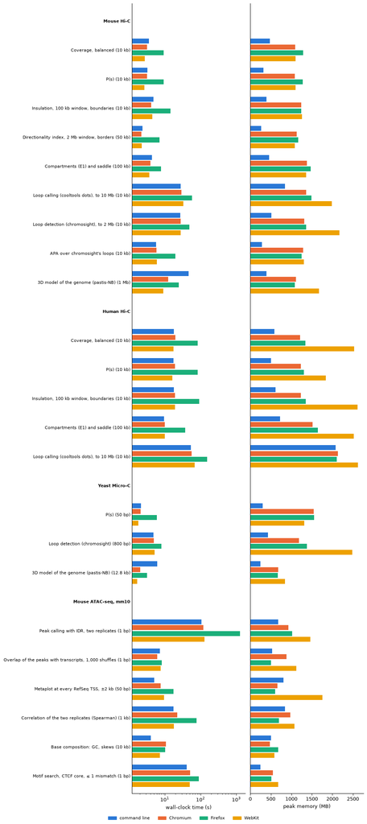

Figure 1: Wall-clock time (left, logarithmic) and peak memory (right) of each analysis, grouped by its data: on the command line and in each browser.

```python
# The first slots of a categorical palette, in their fixed order, one a venue.
colours = dict(zip(VENUES, ['#2a78d6', '#eb6834', '#1baf7a', '#eda100']))
# A row for each data, naming it, and under it a row for each of its analyses, from the top down.
layout = []
for data, names in TASK.reset_index().groupby('data', sort=False)['name']:
    layout += [(data, None)] + [(f"{TASK.loc[name, 'analysis']} ({TASK.loc[name, 'resolution']})", name) for name in names]
y = {name: len(layout) - 1 - at for at, (_, name) in enumerate(layout) if name is not None}
band = 0.8 / len(VENUES)
fig, (left, right) = plt.subplots(1, 2, figsize=(10, (0.15 * len(VENUES) + 0.2) * len(layout) + 1), sharey=True,
                                  layout='constrained')
for ax, measured in ((left, WALL), (right, PEAK)):
    for at, venue in enumerate(VENUES):
        ax.barh([y[name] + 0.4 - band * (at + 0.5) for name in ORDER], measured.loc[ORDER, venue].values,
                height=band * 0.85, color=colours[venue])
    ax.spines[['top', 'right']].set_visible(False)
    ax.tick_params(axis='y', labelsize=8, length=0)
left.set(xscale='log', xlabel='wall-clock time (s)', yticks=list(range(len(layout)))[::-1],
         yticklabels=[label for label, _ in layout], ylim=(-0.6, len(layout) - 0.4))
for tick, (_, name) in zip(left.get_yticklabels(), layout):
    if name is None:
        tick.set_fontweight('bold')
right.set(xlabel='peak memory (MB)')
fig.legend(handles=[Patch(color=colour, label=venue) for venue, colour in colours.items()],
           loc='outside lower center', ncols=len(VENUES), frameon=False, fontsize=8)
plt.show()
```

## Every command

Run from `notebooks/work/laptop/`, each followed by `--out out/<name> --quiet`:

```bash
chromosomix coverage data/4DNFIOZ1TRUS.mcool::/resolutions/10000 --balance
chromosomix expected data/4DNFIOZ1TRUS.mcool::/resolutions/10000 --quantity expected --scope file
chromosomix insulation data/4DNFIOZ1TRUS.mcool::/resolutions/10000 --window 10
chromosomix di data/4DNFIOZ1TRUS.mcool::/resolutions/50000 --window 40
chromosomix compartments data/4DNFIOZ1TRUS.mcool::/resolutions/100000
chromosomix loops data/4DNFIOZ1TRUS.mcool::/resolutions/10000
chromosomix chromosight data/4DNFIOZ1TRUS.mcool::/resolutions/10000 --pattern loops
chromosomix apa data/4DNFIOZ1TRUS.mcool::/resolutions/10000 --pairs out/chromosight/4DNFIOZ1TRUS_10000.chromosight.chromosight-patterns.bedpe
chromosomix reconstruct3d data/4DNFIOZ1TRUS.mcool::/resolutions/1000000 --method nb --alpha 3
chromosomix coverage data/4DNFIJTOIGOI.mcool::/resolutions/10000 --balance
chromosomix expected data/4DNFIJTOIGOI.mcool::/resolutions/10000 --quantity expected --scope file
chromosomix insulation data/4DNFIJTOIGOI.mcool::/resolutions/10000 --window 10
chromosomix compartments data/4DNFIJTOIGOI.mcool::/resolutions/100000
chromosomix loops data/4DNFIJTOIGOI.mcool::/resolutions/10000
chromosomix expected data/GSE151553_A364_merged.mcool::/resolutions/50 --quantity expected --scope file
chromosomix chromosight data/GSE151553_A364_merged.mcool::/resolutions/800 --pattern loops
chromosomix reconstruct3d data/GSE151553_A364_merged.mcool::/resolutions/12800 --method nb --alpha 3
chromosomix peaks --signal data/4DNFIIY4QW2D.bw --replicate data/4DNFITBRHVZE.bw --width 150 --times 3 --minWidth 75 --truncate 100000 --idr 0.05
chromosomix overlap --sequence data/mm10.fa --features out/peaks/4DNFIIY4QW2D.peaks.peaks-data_4DNFIIY4QW2D_bw-data_4DNFITBRHVZE_bw.bed --features data/mm10.genes.gtf --a out/peaks/4DNFIIY4QW2D.peaks.peaks-data_4DNFIIY4QW2D_bw-data_4DNFITBRHVZE_bw.bed --b data/mm10.genes.gtf --shuffle --iterations 1000 --seed 1
chromosomix metaplot --tracks data/4DNFIIY4QW2D.bw --features data/mm10.genes.gtf --mode reference --at start --flank 2000 --step 50 --band none
chromosomix trackcorr --tracks data/4DNFIIY4QW2D.bw,data/4DNFITBRHVZE.bw --binsize 1000 --method spearman
chromosomix composition --sequence data/mm10.fa --resolution 10000
chromosomix motif --sequence data/mm10.fa --pattern CCGCGNGGNGGCAG --mismatches 1
```

And each as the app’s console wrote it, in Chromium where it finished there, and otherwise in the first browser it did: the line it gives a reader to run the same analysis from a shell, in the folder that holds the files, which it names by their own names.

```bash
chromosomix coverage 4DNFIOZ1TRUS.mcool::/resolutions/10000 --window chr1:1-54,620,000 --total --fraction=false --cis=false --trans=false --balance
chromosomix expected 4DNFIOZ1TRUS.mcool::/resolutions/10000 --window chr1:1-54,620,000 --scope file --sequences chr1,chr2,chr3,chr4,chr5,chr6,chr7,chr8,chr9,chr10,chr11,chr12,chr13,chr14,chr15,chr16,chr17,chr18,chr19,chrX,chrY --quantity expected --factor 1.1 --minSeparation 2 --derivative
chromosomix insulation 4DNFIOZ1TRUS.mcool::/resolutions/10000 --window 10 --scales 1 --sequences chr1,chr2,chr3,chr4,chr5,chr6,chr7,chr8,chr9,chr10,chr11,chr12,chr13,chr14,chr15,chr16,chr17,chr18,chr19,chrX,chrY --ignoreDiags 2 --call --prominence 0.2 --minValid 0.5 --spacing 0 --domains
chromosomix di 4DNFIOZ1TRUS.mcool::/resolutions/50000 --window 40 --sequences chr1,chr2,chr3,chr4,chr5,chr6,chr7,chr8,chr9,chr10,chr11,chr12,chr13,chr14,chr15,chr16,chr17,chr18,chr19,chrX,chrY --ignoreDiags 0 --minValid 0.5 --call --prominence 10 --spacing 0 --domains
chromosomix compartments 4DNFIOZ1TRUS.mcool::/resolutions/100000 --sequences chr1,chr2,chr3,chr4,chr5,chr6,chr7,chr8,chr9,chr10,chr11,chr12,chr13,chr14,chr15,chr16,chr17,chr18,chr19,chrX,chrY --contacts cis --ignoreDiags 2 --expected distance --armWindow 50 --method cooltools --components 1 --minR 0.1 --saddle --quantiles 50
chromosomix loops 4DNFIOZ1TRUS.mcool::/resolutions/10000 --window chr1:1-54,620,000 --sequences chr1,chr2,chr3,chr4,chr5,chr6,chr7,chr8,chr9,chr10,chr11,chr12,chr13,chr14,chr15,chr16,chr17,chr18,chr19,chrX,chrY --outer 5 --inner 2 --maxSeparation 1000 --fdr 0.1 --lambdaBins 40 --clusteringRadius 2 --filter
chromosomix chromosight 4DNFIOZ1TRUS.mcool::/resolutions/10000 --window chr1:1-54,620,000 --pattern loops --sequences chr1,chr2,chr3,chr4,chr5,chr6,chr7,chr8,chr9,chr10,chr11,chr12,chr13,chr14,chr15,chr16,chr17,chr18,chr19,chrX,chrY --thresholds preset --pearson 0.3 --minDist 10 --maxDist 1000 --minSeparation 3 --iterations 1 --maxPercUndetected 50 --maxPercZero 10 --nMads 5 --maxQvalue 1
chromosomix apa 4DNFIOZ1TRUS.mcool::/resolutions/10000 --pairs 4DNFIOZ1TRUS_10000.chromosight.chromosight-patterns.bedpe --anchors pairs --mode fixed --at centre --window 21 --grid 51 --flankFraction 0.5 --minDiag 2 --norm oe --csPattern loops --controls 5 --minShift 50 --maxShift 500 --minShiftScale 1 --maxShiftScale 3 --seed 1 --minDist 5 --minSep 2 --maxSep 200 --byDistance 0 --rankBy score --subset all --count 500 --groups 4 --symmetric
chromosomix reconstruct3d 4DNFIOZ1TRUS.mcool::/resolutions/1000000 --method nb --alpha 3 --weights contacts --seed 0 --iterations 150
chromosomix coverage 4DNFIJTOIGOI.mcool::/resolutions/10000 --window chr1:1-61,880,000 --total --fraction=false --cis=false --trans=false --balance
chromosomix expected 4DNFIJTOIGOI.mcool::/resolutions/10000 --window chr1:1-61,880,000 --scope file --sequences chr1,chr2,chr3,chr4,chr5,chr6,chr7,chr8,chr9,chr10,chr11,chr12,chr13,chr14,chr15,chr16,chr17,chr18,chr19,chr20,chr21,chr22,chrX,chrY --quantity expected --factor 1.1 --minSeparation 2 --derivative
chromosomix insulation 4DNFIJTOIGOI.mcool::/resolutions/10000 --window 10 --scales 1 --sequences chr1,chr2,chr3,chr4,chr5,chr6,chr7,chr8,chr9,chr10,chr11,chr12,chr13,chr14,chr15,chr16,chr17,chr18,chr19,chr20,chr21,chr22,chrX,chrY --ignoreDiags 2 --call --prominence 0.2 --minValid 0.5 --spacing 0 --domains
chromosomix compartments 4DNFIJTOIGOI.mcool::/resolutions/100000 --sequences chr1,chr2,chr3,chr4,chr5,chr6,chr7,chr8,chr9,chr10,chr11,chr12,chr13,chr14,chr15,chr16,chr17,chr18,chr19,chr20,chr21,chr22,chrX,chrY --contacts cis --ignoreDiags 2 --expected distance --armWindow 50 --method cooltools --components 1 --minR 0.1 --saddle --quantiles 50
chromosomix loops 4DNFIJTOIGOI.mcool::/resolutions/10000 --window chr1:1-61,880,000 --sequences chr1,chr2,chr3,chr4,chr5,chr6,chr7,chr8,chr9,chr10,chr11,chr12,chr13,chr14,chr15,chr16,chr17,chr18,chr19,chr20,chr21,chr22,chrX,chrY --outer 5 --inner 2 --maxSeparation 1000 --fdr 0.1 --lambdaBins 40 --clusteringRadius 2 --filter
chromosomix expected GSE151553_A364_merged.mcool::/resolutions/50 --circular chrM --scope file --sequences chrI,chrII,chrIII,chrIV,chrV,chrVI,chrVII,chrVIII,chrIX,chrX,chrXI,chrXII,chrXIII,chrXIV,chrXV,chrXVI,chrM --quantity expected --factor 1.1 --minSeparation 2 --derivative
chromosomix chromosight GSE151553_A364_merged.mcool::/resolutions/800 --circular chrM --pattern loops --sequences chrI,chrII,chrIII,chrIV,chrV,chrVI,chrVII,chrVIII,chrIX,chrX,chrXI,chrXII,chrXIII,chrXIV,chrXV,chrXVI,chrM --thresholds preset --pearson 0.3 --minDist 10 --maxDist 1000 --minSeparation 3 --iterations 1 --maxPercUndetected 50 --maxPercZero 10 --nMads 5 --maxQvalue 1
chromosomix reconstruct3d GSE151553_A364_merged.mcool::/resolutions/12800 --method nb --alpha 3 --weights contacts --seed 0 --iterations 150
chromosomix peaks --signal 4DNFIIY4QW2D.bw --replicate 4DNFITBRHVZE.bw --idr 0.05 --sequences chr1,chr10,chr11,chr12,chr13,chr14,chr15,chr16,chr17,chr18,chr19,chr2,chr3,chr4,chr5,chr6,chr7,chr8,chr9,chrX,chrY --perPeak=false --width 150 --times 3 --minWidth 75 --halfWidth 0 --truncate 100000
chromosomix overlap --features 4DNFIIY4QW2D.peaks.peaks-data_4DNFIIY4QW2D_bw-data_4DNFITBRHVZE_bw.bed --features mm10.genes.gtf --a 4DNFIIY4QW2D.peaks.peaks-data_4DNFIIY4QW2D_bw-data_4DNFITBRHVZE_bw.bed --b mm10.genes.gtf --minFraction 0.000001 --shuffle --shuffleWhich a --iterations 1000 --seed 1
chromosomix metaplot --tracks 4DNFIIY4QW2D.bw --features mm10.genes.gtf --mode reference --at start --flank 2000 --step 50 --body 100 --stranded --rankBy score --subset all --count 500 --groups 4 --zscore=false --average mean --band none --iterations 200 --seed 1 --heatmap
chromosomix trackcorr --tracks 4DNFIIY4QW2D.bw --tracks 4DNFITBRHVZE.bw --over bins --binsize 1000 --method spearman
chromosomix composition --sequence mm10.fa --resolution 10000 --window 0 --gc --gcSkew --atSkew --cumulative
chromosomix motif --sequence mm10.fa --sequences chr10,chr11,chr12,chr13,chr14,chr15,chr16,chr17,chr18,chr19,chr1,chr2,chr3,chr4,chr5,chr6,chr7,chr8,chr9,chrM,chrX,chrY --pattern CCGCGNGGNGGCAG --bothStrands --mismatches 1 --limit 500000
```

Every browser wrote the same line, word for word, for every analysis it finished.

```python
def asked(line):
    """What a line asks for, flag by flag: each value as written, a file by its name, a switch as true or
    false — and its map, as `map`."""
    out = {}
    words = shlex.split(line)[2:]
    while words:
        word = words.pop(0)
        if not word.startswith('--'):
            path, _, group = word.partition('::')
            out['map'] = [Path(path).name + (f'::{group}' if group else '')]
            continue
        key, _, value = word[2:].partition('=')
        if not value:
            value = words.pop(0) if words and not words[0].startswith('--') else 'true'
        out.setdefault(key, []).extend(Path(one).name if one.startswith(('data/', 'out/')) else one
                                       for one in value.split(','))
    return {key: ','.join(values) for key, values in out.items()}


def alike(a, b):
    """Two values written alike, or two numbers that are one."""
    try:
        return a == b or float(a) == float(b)
    except ValueError:
        return False


def differences(task, command, line):
    """Where the app's line asks for other than the command does: a flag of the command's it does not
    write as written, and one of its own that is not the task's parameter at its default, or one the
    form answers from what is open."""
    ours, theirs = asked(command), asked(line)
    named = set(','.join(theirs.values()).split(','))
    out = []
    for key, value in ours.items():
        if key in OPENED:
            out += [f'does not name {one}' for one in value.split(',') if one not in named]
        elif not alike(value, theirs.get(key)):
            out.append(f"--{key} {theirs.get(key, '(none)')}, for {value}")
    for key, value in theirs.items():
        if key in ours or (key in PARAMETERS[task] and key not in DEFAULTS[task]):
            continue
        if not alike(value, DEFAULTS[task].get(key)):
            out.append(f'adds --{key} {value}')
    return out


#: Every line a browser wrote, held to the command it ran for: where it asks for anything else, what.
DIFFERENT = {(row['name'], row['venue']): differences(row['command'].split()[1], row['command'], row['line'])
             for _, row in LINES.iterrows()}
DIFFERENT = {run: found for run, found in DIFFERENT.items() if found}
```

Held against the command it ran for, the app’s line asks for the same thing in **39 of 69**, over the 3 browsers: every flag of the command, with the same value, and besides them only the task’s parameters at their defaults and those its form answers from what is open — every sequence ticked, the column a feature set is ranked by. Where it asks for anything else:

- `coverage`, in Chromium: `adds --window chr1:1-54,620,000`
- `coverage`, in Firefox: `adds --window chr1:1-54,620,000`
- `coverage`, in WebKit: `adds --window chr1:1-54,620,000`
- `expected`, in Chromium: `adds --window chr1:1-54,620,000`
- `expected`, in Firefox: `adds --window chr1:1-54,620,000`
- `expected`, in WebKit: `adds --window chr1:1-54,620,000`
- `loops`, in Chromium: `adds --window chr1:1-54,620,000`
- `loops`, in Firefox: `adds --window chr1:1-54,620,000`
- `loops`, in WebKit: `adds --window chr1:1-54,620,000`
- `chromosight`, in Chromium: `adds --window chr1:1-54,620,000`
- `chromosight`, in Firefox: `adds --window chr1:1-54,620,000`
- `chromosight`, in WebKit: `adds --window chr1:1-54,620,000`
- `human-coverage`, in Chromium: `adds --window chr1:1-61,880,000`
- `human-coverage`, in Firefox: `adds --window chr1:1-61,880,000`
- `human-coverage`, in WebKit: `adds --window chr1:1-61,880,000`
- `human-expected`, in Chromium: `adds --window chr1:1-61,880,000`
- `human-expected`, in Firefox: `adds --window chr1:1-61,880,000`
- `human-expected`, in WebKit: `adds --window chr1:1-61,880,000`
- `human-loops`, in Chromium: `adds --window chr1:1-61,880,000`
- `human-loops`, in Firefox: `adds --window chr1:1-61,880,000`
- `human-loops`, in WebKit: `adds --window chr1:1-61,880,000`
- `yeast-expected`, in Chromium: `adds --circular chrM`
- `yeast-expected`, in Firefox: `adds --circular chrM`
- `yeast-expected`, in WebKit: `adds --circular chrM`
- `yeast-chromosight`, in Chromium: `adds --circular chrM`
- `yeast-chromosight`, in Firefox: `adds --circular chrM`
- `yeast-chromosight`, in WebKit: `adds --circular chrM`
- `overlap`, in Chromium: `does not name mm10.fa`
- `overlap`, in Firefox: `does not name mm10.fa`
- `overlap`, in WebKit: `does not name mm10.fa`

## A deep human map, start to finish

Each analysis above is one command, timed alone, and by chromosomix alone. This last part times what a reader runs on a deep map, and against the packages chromosomix reproduces: six analyses, one after the other, over the human map above — 4DN’s in situ Hi-C of IMR-90 (Rao et al. 2014; 4DNFIJTOIGOI, GRCh38, 1.08 billion contacts, an 8.3 GB `.mcool`) — each over the whole genome, with the settings its section of [`validation.qmd`](https://chromosomix.app/validation/) holds it to:

1. **Loop calling** at 10 kb: HiCCUPS as `cooltools.dots` computes it, at its Python API’s defaults, over the expected with the first two diagonals left out (§ 19);
2. **Diamond insulation** at 10 kb, a window of 10 bins, 100 kb, and its boundaries (§ 1);
3. **Compartments** at 250 kb: three cis eigenvectors, signed by each bin’s GC content, which is worked out once beforehand — `bioframe.frac_gc` over hg38 as Illumina iGenomes distributes UCSC’s — and given to both (§ 3);
4. **APA over every loop** step 1 called: five bins either side of each, ±50 kb, of balanced counts with no expected — the pileup raw — the first two diagonals left out and no loop for being near the diagonal (§ 11, *raw, every loop*);
5. **P(s)** at 10 kb: the mean balanced contact at each separation, over every chromosome, every diagonal kept, cooltools’ `expected_cis` unsmoothed and pooled over the bands chromosomix writes (§ 4) — its own, not the one step 1 read, which left two diagonals out;
6. **Virtual 4C** at 10 kb: what one bin, the one holding *MYC*’s transcription start on chr8, touches over the whole genome, balanced, as § 10 reads it — chromosomix’s `fourc` with `--no-cis` (in the app, *cis only* off), `cooltools.virtual4c` as it is.

Five sides run them. **chromosomix on the command line** runs them as a shell script would: six commands, one after the other, the pileup reading the loops the first wrote. **chromosomix in Chromium** runs them as a reader does in the app, in one page: the map opened once, at 10 kb, balanced, its whole genome on screen, with the GC content beside it as a track; then each task opened from the Analysis panel, its form set as the command’s flags set it, and run, one after the other, the pileup over the loops the first called in the same page, and the map moved to 250 kb for the compartments and back, in the crumb row’s resolution. It is left out where `LAPTOP_BROWSERS` leaves Chromium out. **The reference** is one Python script, `notebooks/scripts/cooltools_pipeline.py`, which runs the six through cooltools and coolpuppy in one process, its pileup over the loops `cooltools.dots` called — twice: on **one process**, as chromosomix computes, and on **`P_THREADS` processes**, which it gives every call that takes them — one a core, at most four, as the validation gives its references; the compartments’ `eigs_cis` takes none, and runs on one either way. Its pools fork, on a Mac as on Linux: coolpuppy’s works no other way. And **the reference’s own commands** run them as chromosomix’s do, one after another on `P_THREADS` processes: `cooltools expected-cis` and `dots`, `insulation`, `eigs-cis`, coolpuppy’s `coolpup.py` over the loops `dots` wrote, `expected-cis` again and `virtual4c` (`reference_argv` below), each set to what the script asks of the Python API where the command’s default is another, and each paying its own start-up and reading the map again. coolpup.py needs three things its package does not bring, which the environment adds: PyTables, which it writes its pileup with; setuptools 81.0.0, the last to ship the `pkg_resources` its h5sparse calls; and, on a Mac, multiprocessing-logging 0.3.4, as 0.4.0 refuses to log from the workers macOS spawns. No side’s pileup reads an expected, so none is spared one another pays for, and each side’s P(s) is a step of its own, as the loop calling’s expected is inside its own; chromosomix’s compartments draw the saddle too, at the task’s default, which `cooltools.eigs_cis` does not. This part alone needs the reference packages, at the versions `notebooks/requirements.txt` pins: cooler, cooltools, coolpuppy and bioframe.

**Start-up, each step and the whole.** A command’s start-up is the program loaded and nothing done, `chromosomix --version`, timed as a command of its own, which each of the six pays again before its task: each step is its command, from its launch to its exit, its own start-up and the opening of the map included, and the whole is the six. The script’s start-up runs from its launch to the end of its imports — Python itself, cooler, cooltools and coolpuppy — and each step from the end of the one before it to its own, as the script writes them down; the whole is the process, from its launch to its exit. The CPU time of a command, and of the script’s whole, is `os.wait4`‘s, as above; a step of the script’s, what its process and every child it had waited for had used at either end — cooltools’ and coolpuppy’s pools are waited for when each call returns. The memory is weighed every `EVERY` seconds: the process and every process under it, together — their proportional set sizes where the system gives them, as Linux does, a page two of them share counted half in each; elsewhere, as on a Mac, their resident sets as `ps` lists them, a page shared counted in each, so that a pool of forked workers reads as more than it holds. A command’s peak, and the script’s whole, is never less than the largest resident set any one of its processes reached, which a weighing can miss; a step of the script’s, the most its processes held together in the weighings taken between its ends.

**In Chromium** (`laptop.mjs`), the browser is launched as for the analyses above and its processes weighed every fifth of a second, from the drop of the files to the last run’s end; what the page holds and spends is its processes’, the renderers whose threads its workers are, as above. Three kinds of stretch are measured: the **opening**, from the drop of the map and its track to the map drawn, which is this side’s start-up, paid once; a **move** to another rung, from the pick to the map drawn at it, inside the step that needed it; and each **run**, from the press to the console’s record of its end, its time the console’s own. What lies between them — a form being set, the wait for the browser to be idle before a press, as before each analysis above — is the script’s and not the app’s, and is left out: the stretches are laid end to end, as the commands are, and the weighings within each with them.

**One run of each side, unless `PIPELINE_RUNS` says otherwise.** Each side reads the map from the disk, the page cache emptied before it where the machine lets the benchmark do so; where it does not, as on a Mac, the map is read through once before each side instead, so that each finds it in memory (the `page_cache` column). Over several runs each begins one side further along, so that over as many runs as there are sides each has gone first once. Every step of every run, its start-up and the whole among them, is one line of **`notebooks/work/laptop/pipeline.tsv`**, with when in its side’s run it began and ended; and every weighing of each side’s processes, with when it was taken and the step it fell in, is one line of **`pipeline-memory.tsv`** beside it, which the figure at the end draws against the time. The page carries both, as it carries the table above. A second render reads them back (`REDO_PIPELINE`), unless the build, the script, the browser, the sides or the number of runs has changed.

```python
from importlib.metadata import version as installed_version
import threading

import cooler
import numpy as np

#: Runs of each side (PIPELINE_RUNS overrides it), and whether to time them again. One: loop calling over
#: a whole human genome is the longest command on the page.
PIPELINE_RUNS = int(os.environ.get('PIPELINE_RUNS', 1))
REDO_PIPELINE = False
PWORK = WORK / 'pipeline'
PIPELINE_TABLE = WORK / 'pipeline.tsv'
PWORK.mkdir(parents=True, exist_ok=True)
IMR90, HG38 = DATA / '4DNFIJTOIGOI.mcool', DATA / 'hg38.fa'
#: The two sides' colours, as notebooks/scripts/timing.plot.R draws them, and the ink of a line drawn over both.
APP_COLOUR, REF, INK2 = '#2a78d6', '#eb6834', '#52514e'


def show(frame, precision=2, **formats):
    """A table without row numbers: the columns named in `formats` their way, the others to `precision`."""
    return frame.style.hide(axis='index').format(formats or None, precision=precision)


def measures(values):
    """Named numbers as a two-column table."""
    return pd.DataFrame(list(values.items()), columns=['measure', 'value']).style.hide(axis='index')


# The GC content of each 250-kb bin of the map, once: a table for cooltools, a bedGraph for chromosomix.
GC_TSV, GC_BEDGRAPH = PWORK / 'gc-250kb.tsv', PWORK / 'gc-250kb.bedGraph'
if REDO_PIPELINE or not GC_TSV.exists():
    import bioframe

    pyfaidx.Faidx(str(HG38)).close()
    _bins = cooler.Cooler(f'{IMR90}::/resolutions/250000').bins()[['chrom', 'start', 'end']][:]
    _gc = bioframe.frac_gc(_bins, bioframe.load_fasta(str(HG38), engine='pyfaidx'))
    _gc.to_csv(GC_TSV, sep='\t', index=False)
    _gc.dropna()[['chrom', 'start', 'end', 'GC']].to_csv(GC_BEDGRAPH, sep='\t', header=False, index=False)
_c10 = cooler.Cooler(f'{IMR90}::/resolutions/10000')
_gc_bins = pd.read_csv(GC_TSV, sep='\t')
measures({'map': f"{IMR90.name} ({IMR90.stat().st_size / 1e9:.1f} GB): {len(_c10.chromnames)} sequences, "
                 f"{_c10.info['sum']:,} contacts",
          'at 10 kb': f"{_c10.info['nbins']:,} bins, {_c10.info['nnz']:,} pixels",
          'at 250 kb, GC content': f"{len(_gc_bins):,} bins, {int(_gc_bins['GC'].notna().sum()):,} with sequence",
          'sequence': f'{HG38.name} ({HG38.stat().st_size / 1e9:.1f} GB)'})
```

| measure | value |
| --- | --- |
| map | 4DNFIJTOIGOI.mcool (8.3 GB): 24 sequences, 1,082,513,502 contacts |
| at 10 kb | 308,837 bins, 402,676,712 pixels |
| at 250 kb, GC content | 12,366 bins, 11,769 with sequence |
| sequence | hg38.fa (3.2 GB) |

```python
#: How often, in seconds, a side's processes are weighed while it runs.
EVERY = 0.25
#: Whether the system gives each process's proportional set size, as Linux does: where it does not, as a
#: Mac does not, a process weighs its resident set.
PSS = Path('/proc/self/smaps_rollup').exists()


def pss_kb(pid):
    """A process's proportional set size, in kB: its resident pages, one it shares with others counted as its
    share of it, so that a pool of forked workers is not counted again in each."""
    try:
        with open(f'/proc/{pid}/smaps_rollup') as handle:
            return next(int(line.split()[1]) for line in handle if line.startswith('Pss:'))
    except (OSError, StopIteration):
        return 0


def held_kb(pid):
    """What `pid` and every process under it hold together, in kB, found by their parents as `ps` lists them,
    on Linux and on a Mac alike: their proportional set sizes where the system gives them, and their resident
    sets elsewhere."""
    listed = subprocess.run(['ps', '-A', '-o', 'pid=,ppid=,rss='], capture_output=True, text=True).stdout.split()
    children, rss = {}, {}
    for at in range(0, len(listed) - 2, 3):
        one, parent, kb = (int(value) for value in listed[at:at + 3])
        children.setdefault(parent, []).append(one)
        rss[one] = kb
    found, todo = [], [pid]
    while todo:
        one = todo.pop()
        found.append(one)
        todo += children.get(one, [])
    return sum(pss_kb(one) if PSS else rss.get(one, 0) for one in found)


def weigh(pid, done, peak, samples=None):
    """Every EVERY seconds until `done`, the processes under `pid` weighed together, the most into `peak[0]`,
    and each weighing into `samples`, with when it was taken, where there is a list to keep them."""
    while True:
        held = held_kb(pid)
        peak[0] = max(peak[0], held)
        if samples is not None:
            samples.append((time.time(), held))
        if done.wait(EVERY):
            return


def timed(argv, cwd, samples=None):
    """One run, from `cwd`: CPU seconds of the process and every process it started and waited for, wall
    seconds, and the most memory they held together, in MB; every weighing of them into `samples`, if it is
    a list."""
    with tempfile.TemporaryFile() as err:
        start = time.perf_counter()
        process = subprocess.Popen(argv, cwd=cwd, stdout=subprocess.DEVNULL, stderr=err)
        done, peak = threading.Event(), [0]
        weigher = threading.Thread(target=weigh, args=(process.pid, done, peak, samples), daemon=True)
        weigher.start()
        _, status, usage = os.wait4(process.pid, 0)
        wall = time.perf_counter() - start
        done.set()
        weigher.join()
        if os.waitstatus_to_exitcode(status):
            err.seek(0)
            raise RuntimeError(f'{shlex.join(argv)}\n{err.read().decode(errors="replace")[-3000:]}')
    # ru_maxrss, the largest resident set any one of the processes reached, which a weighing can miss: in
    # kilobytes on Linux and in bytes on a Mac.
    largest = usage.ru_maxrss / (2**20 if sys.platform == 'darwin' else 2**10)
    return {'cpu_s': usage.ru_utime + usage.ru_stime, 'wall_s': wall, 'peak_mb': max(peak[0] / 1024, largest)}
```

The commands, from `notebooks/work/laptop/pipeline/`, as the first run wrote them; each run writes into a folder of its own side, emptied before it:

```python
PIPELINE_SCRIPT = REPO / 'notebooks' / 'scripts' / 'cooltools_pipeline.py'
#: The six steps, in their order: what the tables call each, and what it reads.
PIPELINE_STEPS = {'loops': ('Loop calling', '10 kb'), 'insulation': ('Diamond insulation', '10 kb, 10 bins'),
                  'compartments': ('Compartments', '250 kb, GC-phased'),
                  'apa': ('APA over every loop', '10 kb, ±5 bins, raw'),
                  'ps': ('P(s)', '10 kb, every diagonal'), 'fourc': ('Virtual 4C', '10 kb, one bin, genome-wide')}
#: The 4C's viewpoint: the 10-kb bin holding MYC's transcription start, chr8:127,735,434 in GRCh38 (+ strand), as
#: cooltools reads a region (0-based, half-open) and as chromosomix does (1-based, inclusive).
FOURC_BIN = ('chr8', 127_730_000, 127_740_000)
FOURC_COOLTOOLS = f'{FOURC_BIN[0]}:{FOURC_BIN[1]}-{FOURC_BIN[2]}'
FOURC_ANCHOR = f'{FOURC_BIN[0]}:{FOURC_BIN[1] + 1:,}-{FOURC_BIN[2]:,}'
#: And the start-up before them, and the whole of them.
PIPELINE_TASKS = {'start-up': ('Start-up', ''), **PIPELINE_STEPS, 'total': ('Total', '')}


def in_a_sentence(name):
    """A step's name inside a sentence: its first letter lowered, unless what follows it is not a small letter
    (APA, P(s))."""
    return name[0].lower() + name[1:] if name[1:2].islower() else name

#: The script's processes on its last side: one a core, at most four, as validation.qmd's THREADS gives its
#: references.
P_THREADS = min(4, os.cpu_count() or 1)
_REFERENCE = ', '.join(f'{name} {installed_version(name)}' for name in ('cooltools', 'coolpuppy', 'cooler'))
#: The sides, in the order the tables and the figure give them, each with the tool the tables name, its
#: version, and the processes it computes on: chromosomix on the command line, and in Chromium where
#: LAPTOP_BROWSERS has it; then the reference's own commands on P_THREADS processes, its script on as many,
#: and its script on one, where the machine has more than one core.
P_SIDES = {'chromosomix': {'tool': 'chromosomix', 'version': MACHINE['chromosomix'], 'threads': 1}}
if 'chromium' in BROWSERS:
    P_SIDES['chromium'] = {'tool': 'chromosomix', 'threads': 1,
                           'version': f"{MACHINE['chromosomix']}, Chromium {VERSIONS['chromium']}"}
P_SIDES['reference-cli'] = {'tool': 'cooltools, coolpup.py', 'version': _REFERENCE, 'threads': P_THREADS}
P_SIDES['reference'] = {'tool': 'cooltools, coolpuppy', 'version': _REFERENCE, 'threads': P_THREADS}
if P_THREADS > 1:
    P_SIDES['reference-1'] = {'tool': 'cooltools, coolpuppy', 'version': _REFERENCE, 'threads': 1}
#: How the tables and the figures name each side.
_PROCESSES = f"{P_THREADS} process{'es' if P_THREADS > 1 else ''}"
P_SIDE_LABELS = {'chromosomix': 'chromosomix, command line', 'chromium': 'chromosomix, Chromium',
                 'reference-1': 'cooltools, coolpuppy, 1 process', 'reference': f'cooltools, coolpuppy, {_PROCESSES}',
                 'reference-cli': f'cooltools, coolpup.py commands, {_PROCESSES}'}
#: The reference packages' own command lines, from the environment's: cooltools, and coolpuppy's coolpup.py.
COOLTOOLS, COOLPUP = Path(sys.executable).parent / 'cooltools', Path(sys.executable).parent / 'coolpup.py'
P_SCRIPT = hashlib.sha256(PIPELINE_SCRIPT.read_bytes()).hexdigest()[:10]
P_OUT = {side: PWORK / 'runs' / side for side in P_SIDES}


def p_rel(path):
    return os.path.relpath(path, PWORK)


def p_map(bp):
    return f'{p_rel(IMR90)}::/resolutions/{bp}'


def app_argv(step, out, pairs=None):
    """chromosomix's command for one step, writing into `out`: the pileup reads the loops the first wrote there,
    or the `pairs` named."""
    program = ['node', p_rel(CLI)]
    if step == 'start-up':
        return [*program, '--version']
    argv = {'loops': ['loops', p_map(10_000)],
            'insulation': ['insulation', p_map(10_000), '--window', '10'],
            'compartments': ['compartments', p_map(250_000), '--components', '3', '--phaseTrack', p_rel(GC_BEDGRAPH)],
            'ps': ['expected', p_map(10_000), '--quantity', 'expected', '--scope', 'file'],
            'fourc': ['fourc', p_map(10_000), '--anchor', FOURC_ANCHOR, '--no-cis']}
    if step == 'apa':
        pairs = pairs if pairs is not None else p_rel(one_file(out / 'loops', '*.loops-calls.bedpe'))
        argv['apa'] = ['apa', p_map(10_000), '--pairs', pairs,
                       '--mode', 'fixed', '--window', '5', '--minDiag', '2', '--minDist', '0', '--norm', 'none']
    return [*program, *argv[step], '--out', p_rel(out / step)]


def reference_argv(step, out):
    """The reference's own commands for one step, writing into `out`, each set to what the script asks of the
    Python API where the command's default is another: `dots` defaults to 2 Mb, 45 λ-bins, an FDR of 0.02
    and a 39-kb radius where the API has 10 Mb, 40, 0.1 and 20 kb, and to tiles of 6 Mb where it has 5;
    `expected-cis` smooths only when asked, which the API does unasked, and the expected `dots` reads is
    this one; `insulation` thresholds at 0 unless told; coolpup.py takes ten shifted controls per window and
    divides by an expected unless told not to, which the API's `pileup` does not. The start-up is
    `cooltools --version`; coolpup.py's own is paid inside its step."""
    threads, at = str(P_THREADS), lambda name: p_rel(out / name)
    if step == 'start-up':
        return [[str(COOLTOOLS), '--version']]
    commands = {
        'loops': [[str(COOLTOOLS), 'expected-cis', p_map(10_000), '--ignore-diags', '2', '--smooth', '--aggregate-smoothed',
                   '-p', threads, '-o', at('expected-loops.tsv')],
                  [str(COOLTOOLS), 'dots', p_map(10_000), f"{at('expected-loops.tsv')}::balanced.avg",
                   '--max-loci-separation', '10000000', '--max-nans-tolerated', '1', '--tile-size', '5000000',
                   '--num-lambda-bins', '40', '--fdr', '0.1', '--clustering-radius', '20000', '-p', threads,
                   '-o', at('loops.tsv')]],
        'insulation': [[str(COOLTOOLS), 'insulation', p_map(10_000), '100000', '--ignore-diags', '2',
                        '--min-frac-valid-pixels', '0.5', '--threshold', '0.2', '-p', threads, '-o', at('insulation.tsv')]],
        'compartments': [[str(COOLTOOLS), 'eigs-cis', p_map(250_000), '--phasing-track', f'{p_rel(GC_TSV)}::GC',
                          '--n-eigs', '3', '--ignore-diags', '2', '-o', at('compartments')]],
        'apa': [[str(COOLPUP), p_map(10_000), at('loops.tsv'), '--features_format', 'bedpe', '--flank', '50000',
                 '--nshifts', '0', '--not_ooe', '--mindist', '0', '--ignore_diags', '2', '-p', threads,
                 '-o', at('apa.clpy')]],
        'ps': [[str(COOLTOOLS), 'expected-cis', p_map(10_000), '--ignore-diags', '0', '-p', threads, '-o', at('ps.tsv')]],
        'fourc': [[str(COOLTOOLS), 'virtual4c', p_map(10_000), FOURC_COOLTOOLS, '-p', threads, '-o', at('fourc')]],
    }
    return commands[step]
```

```python
def script_argv(out, threads):
    """The script's one command on `threads` processes, writing beside `out/cooltools` and its marks to
    `out/marks.json`."""
    return [sys.executable, p_rel(PIPELINE_SCRIPT), p_rel(IMR90), p_rel(GC_TSV), FOURC_COOLTOOLS,
            p_rel(out / 'cooltools'), str(threads), p_rel(out / 'marks.json')]


#: The pileup's pairs in the app: the loops the first step called in the same page, which the app keeps as a
#: row of the Tracks card and the form lists among the sets of pairs, by this name.
APP_LOOPS = 'loops'


def app_step(step):
    """A step as the app runs it: its task's title in the Analysis panel, the rung its map is read at, and its
    form as its command's flags set it — the GC content's bedGraph chosen by its name among the tracks open,
    the pileup's pairs the loops the first step called — and no track ticked that the command does not name:
    the pileup's form ticks every track open for an aggregate of its own, which the command does not ask for."""
    _, _, task, the_map, *words = app_argv(step, P_OUT['chromosomix'], pairs='')[:-2]
    form, flags = [], list(words)
    while flags:
        key = flags.pop(0)[2:]
        # A switch turned off, `--no-cis`: the form's switch, off.
        if key.startswith('no-'):
            form.append({'key': key[3:], 'on': False})
            continue
        value = flags.pop(0)
        if key == 'pairs':
            form.append({'key': key, 'option': APP_LOOPS})
        elif key == 'phaseTrack':
            form.append({'key': key, 'option': stem(value)})
        else:
            form.append({'key': key, 'value': value})
    if 'tracks' in PARAMETERS[task] and '--tracks' not in words:
        form.append({'key': 'tracks', 'ticks': []})
    return {'step': step, 'task': TITLES[task], 'binsize': int(the_map.rsplit('/', 1)[1]), 'set': form}


def browser_plan(out):
    """What laptop.mjs is handed for the six in Chromium: the map opened at the first step's rung, balanced,
    its whole genome on screen, with the GC content beside it as a track, and the steps in turn."""
    steps = [app_step(step) for step in PIPELINE_STEPS]
    gc = {'id': 'gc', 'card': 'linear', 'kind': 'track', 'label': stem(GC_BEDGRAPH),
          'source': {'kind': 'local', 'name': GC_BEDGRAPH.name}, 'visible': True,
          'placement': {'bottom': True, 'right': False}}
    return {'name': 'pipeline', 'browser': 'chromium', 'app': str(APP), 'data': str(PWORK), 'out': str(out),
            'executablePath': EXECUTABLES.get('chromium'), 'files': [p_rel(IMR90), p_rel(GC_BEDGRAPH)],
            'workspace': {'kind': 'chromosomix.workspace', 'version': 1, 'active': 0, 'tabs': [{'version': 1, 'state': {
                'uri': f"{IMR90.name}::/resolutions/{steps[0]['binsize']}", 'view': 'whole', 'balance': True},
                'tracks': [gc]}]},
            'steps': steps}


def one_file(folder, pattern):
    hits = sorted(Path(folder).glob(pattern))
    if len(hits) != 1:
        raise FileNotFoundError(f'{len(hits)} files match {pattern} in {folder}')
    return hits[0]


def typed_line(argv):
    """A command as a reader would type it."""
    if argv[:2] == ['node', p_rel(CLI)]:
        argv = ['chromosomix', *argv[2:]]
    elif argv[0] in (str(COOLTOOLS), str(COOLPUP)):
        argv = [Path(argv[0]).name, *argv[1:]]
    return shlex.join(['python' if a == sys.executable else a for a in argv])


def settle():
    """Before each side: the page cache emptied where the machine lets the benchmark do so, so that each reads
    the map from the disk, as at a first opening; elsewhere the map read through once, so that each finds it
    in memory. Which of the two, as the table says it."""
    subprocess.run(['sync'])
    try:
        if subprocess.run(['sudo', '-n', 'sh', '-c', 'echo 3 > /proc/sys/vm/drop_caches'],
                          capture_output=True).returncode == 0:
            return 'dropped'
    except FileNotFoundError:
        pass
    with open(IMR90, 'rb') as handle:
        while handle.read(1 << 24):
            pass
    return 'read through'


#: The columns of pipeline.tsv, in order: the side and the step, the run, what it cost, when in the side's
#: run it began and ended (`from_s`, `to_s`, seconds since the side's first launch), where.
PIPELINE_COLUMNS = ['side', 'tool', 'version', 'step', 'task', 'reads', 'run', 'went_first', 'page_cache',
                    'threads', 'cpu_s', 'wall_s', 'peak_mb', 'from_s', 'to_s', 'started', *MACHINE, 'python',
                    'script', 'map', 'command_line']
#: Every weighing of a side's processes, by the step it fell in: seconds since the side's first launch, and
#: the memory they held together, in MB. What the figure draws against the time.
PIPELINE_TRACE = WORK / 'pipeline-memory.tsv'
TRACE_COLUMNS = ['side', 'tool', 'run', 'step', 'seconds', 'mb']


def p_row(side, step, run, first, cache, cost, line, started, span=(np.nan, np.nan)):
    return {'side': side, 'tool': P_SIDES[side]['tool'], 'version': P_SIDES[side]['version'], 'step': step,
            'task': PIPELINE_TASKS[step][0], 'reads': PIPELINE_TASKS[step][1], 'run': run,
            'went_first': first == side, 'page_cache': cache, 'threads': P_SIDES[side]['threads'],
            'cpu_s': cost['cpu_s'], 'wall_s': cost['wall_s'], 'peak_mb': cost['peak_mb'], 'from_s': span[0],
            'to_s': span[1], 'started': started, **MACHINE, 'python': platform.python_version(), 'script': P_SCRIPT,
            'map': IMR90.name, 'command_line': line}


def p_trace(side, run, step, at, kb):
    return {'side': side, 'tool': P_SIDES[side]['tool'], 'run': run, 'step': step, 'seconds': at, 'mb': kb / 1024}


def commands_side(side, run, first):
    """A side of commands, one run: its start-up, the commands of its six steps and their whole, and every
    weighing of them, its time counted from the launch of the first. The start-up, `--version`, is timed before
    them and is no part of that time: each command pays its own, inside its step. A step of several commands
    — cooltools' loop calling, its expected and then `dots` — is the stretch from the first's launch to the
    last's exit, its CPU time theirs together and its peak the largest of theirs."""
    out = P_OUT[side]
    shutil.rmtree(out, ignore_errors=True)
    out.mkdir(parents=True)
    cache, rows, trace, first_launch = settle(), [], [], None
    for step in ['start-up', *PIPELINE_STEPS]:
        started = time.strftime('%Y-%m-%dT%H:%M:%S')
        cost, lines, begun = {'cpu_s': 0.0, 'wall_s': 0.0, 'peak_mb': 0.0}, [], None
        for argv in P_COMMANDS[side](step, out):
            samples = None if step == 'start-up' else []
            launched = time.time()
            one = timed(argv, PWORK, samples)
            cost = {'cpu_s': cost['cpu_s'] + one['cpu_s'], 'wall_s': cost['wall_s'] + one['wall_s'],
                    'peak_mb': max(cost['peak_mb'], one['peak_mb'])}
            lines.append(typed_line(argv))
            begun = launched if begun is None else begun
            if step != 'start-up':
                first_launch = launched if first_launch is None else first_launch
                trace += [p_trace(side, run, step, at - first_launch, kb) for at, kb in samples]
        span = (np.nan, np.nan) if step == 'start-up' else (begun - first_launch, begun + cost['wall_s'] - first_launch)
        rows.append(p_row(side, step, run, first, cache, cost, '; '.join(lines), started, span))
    steps = rows[1:]
    whole = {'cpu_s': sum(r['cpu_s'] for r in steps), 'wall_s': sum(r['wall_s'] for r in steps),
             'peak_mb': max(r['peak_mb'] for r in steps)}
    rows.append(p_row(side, 'total', run, first, cache, whole,
                      '; '.join(r['command_line'] for r in steps), steps[0]['started'], (0.0, steps[-1]['to_s'])))
    return rows, trace
```

```python
def script_side(run, first, side):
    """The script's side of one run, on the processes `side` gives it: its start-up and six steps as it marked
    them, and its whole, and every weighing of its processes, its time counted from the script's launch."""
    out = P_OUT[side]
    shutil.rmtree(out, ignore_errors=True)
    out.mkdir(parents=True)
    cache, samples = settle(), []
    argv = script_argv(out, P_SIDES[side]['threads'])
    started = time.strftime('%Y-%m-%dT%H:%M:%S')
    launched = time.time()
    whole = timed(argv, PWORK, samples)
    marks = {mark['step']: mark for mark in json.loads((out / 'marks.json').read_text())['marks']}
    rows, trace, before = [], [], {'time': launched, 'cpu_s': 0.0}
    ends = [('start-up', marks['imported']), *((step, marks[step]) for step in PIPELINE_STEPS)]
    for step, mark in ends:
        held = [kb for at, kb in samples if before['time'] <= at <= mark['time']]
        cost = {'cpu_s': mark['cpu_s'] - before['cpu_s'], 'wall_s': mark['time'] - before['time'],
                'peak_mb': max(held) / 1024 if held else np.nan}
        rows.append(p_row(side, step, run, first, cache, cost, typed_line(argv), started,
                          (before['time'] - launched, mark['time'] - launched)))
        before = mark
    rows.append(p_row(side, 'total', run, first, cache, whole, typed_line(argv), started, (0.0, whole['wall_s'])))
    # A weighing in the step whose end is the first after it; one after the last mark, as the process exits, in
    # the last step.
    for at, kb in samples:
        step = next((step for step, mark in ends if at <= mark['time']), ends[-1][0])
        trace.append(p_trace(side, run, step, at - launched, kb))
    return rows, trace


def browser_side(run, first):
    """chromosomix's side in Chromium, one run: the map's opening, which is its start-up, and the six steps, a
    step's move to another rung inside it, laid end to end — what the page did between them, its form being
    set and the wait for the browser to be idle, left out — and every weighing of the page's processes within
    them, its time counted along the same line."""
    out = P_OUT['chromium']
    shutil.rmtree(out, ignore_errors=True)
    out.mkdir(parents=True)
    cache = settle()
    started = time.strftime('%Y-%m-%dT%H:%M:%S')
    (out / 'plan.json').write_text(json.dumps(browser_plan(out), indent=1))
    driven = subprocess.run(['node', str(DRIVER), str(out / 'plan.json'), str(out / 'result.json')],
                            capture_output=True, text=True)
    if not (out / 'result.json').exists():
        raise RuntimeError(f'{DRIVER.name} wrote no result for the deep map in Chromium:\n{driven.stderr[-3000:]}')
    result = json.loads((out / 'result.json').read_text())
    if result['status'] != 'ok':
        raise RuntimeError(f"The deep map did not finish in Chromium: {result.get('error', 'failed')} "
                           f"({out / 'browser.png'} is the page at its end).")
    rows, trace, at = [], [], 0.0
    for done in result['steps']:
        begun = at
        for stretch in done['stretches']:
            # A run's time is the console's, as in the analyses above; a move's and the opening's, the script's.
            wall = stretch.get('wall_s', (stretch['t1'] - stretch['t0']) / 1000)
            trace += [p_trace('chromium', run, done['step'], at + (one['t'] - stretch['t0']) / 1000, one['page_mb'] * 1024)
                      for one in result['trace'] if stretch['t0'] <= one['t'] <= stretch['t0'] + wall * 1000]
            at += wall
        cost = {'cpu_s': sum(one['cpu_s'] for one in done['stretches']), 'wall_s': at - begun,
                'peak_mb': max(one['peak_mb'] for one in done['stretches'])}
        line = done.get('line') or f'{IMR90.name} and {GC_BEDGRAPH.name} dropped on the page'
        rows.append(p_row('chromium', done['step'], run, first, cache, cost, line, started, (begun, at)))
    whole = {'cpu_s': sum(row['cpu_s'] for row in rows), 'wall_s': at, 'peak_mb': max(row['peak_mb'] for row in rows)}
    rows.append(p_row('chromium', 'total', run, first, cache, whole, '; '.join(row['command_line'] for row in rows[1:]),
                      started, (0.0, at)))
    return rows, trace


#: The commands of each side of commands, a step's list of them.
P_COMMANDS = {'chromosomix': lambda step, out: [app_argv(step, out)], 'reference-cli': reference_argv}
#: How each side runs.
P_RUN = {'chromium': browser_side,
         **{side: (lambda run, first, side=side: commands_side(side, run, first)) for side in P_COMMANDS},
         **{side: (lambda run, first, side=side: script_side(run, first, side)) for side in ('reference-1', 'reference')}}


def pipeline():
    rows, trace = [], []
    PIPELINE_TABLE.parent.mkdir(parents=True, exist_ok=True)
    sides = list(P_SIDES)
    for run in range(1, PIPELINE_RUNS + 1):
        # Each run begins one side further along, so that over as many runs as there are sides each goes first once.
        order = sides[(run - 1) % len(sides):] + sides[:(run - 1) % len(sides)]
        for side in order:
            got, weighed = P_RUN[side](run, order[0])
            rows += got
            trace += weighed
        # Written after every run, so a long benchmark that is stopped keeps the runs it finished.
        pd.DataFrame(rows, columns=PIPELINE_COLUMNS).to_csv(PIPELINE_TABLE, sep='\t', index=False)
        pd.DataFrame(trace, columns=TRACE_COLUMNS).to_csv(PIPELINE_TRACE, sep='\t', index=False, float_format='%.6g')


def pipeline_current():
    """Whether pipeline.tsv holds every step of PIPELINE_RUNS runs of every side, by this chromosomix, this
    Chromium and this script, and pipeline-memory.tsv their weighings."""
    if REDO_PIPELINE or not PIPELINE_TABLE.exists() or not PIPELINE_TRACE.exists():
        return False
    held = pd.read_csv(PIPELINE_TABLE, sep='\t', keep_default_na=False, dtype={'version': str})
    return (list(held.columns) == PIPELINE_COLUMNS and set(held['run']) == set(range(1, PIPELINE_RUNS + 1))
            and set(held['side']) == set(P_SIDES) and len(held) == PIPELINE_RUNS * len(P_SIDES) * len(PIPELINE_TASKS)
            and all(set(held.loc[held['side'] == side, 'version']) == {spec['version']} for side, spec in P_SIDES.items())
            and set(held['chromosomix']) == {MACHINE['chromosomix']} and set(held['script']) == {P_SCRIPT}
            and all(P_OUT[side].exists() for side in P_SIDES))
```

```python
if not pipeline_current():
    pipeline()
steps = pd.read_csv(PIPELINE_TABLE, sep='\t', keep_default_na=False, na_values=[''])
weighed = pd.read_csv(PIPELINE_TRACE, sep='\t')
for side, rows in steps.groupby('side', sort=False):
    print(f'# {P_SIDE_LABELS[side]}')
    lines = rows.loc[(rows['run'] == 1) & ~rows['step'].isin(['total']), 'command_line']
    print('\n'.join(f'$ {line}' for line in dict.fromkeys(lines)), end='\n\n')
measures({'runs': PIPELINE_RUNS, 'lines in the table': len(steps),
          'measured': f"{steps['started'].min()} to {steps['started'].max()}",
          'page cache before each side': ', '.join(sorted(set(steps['page_cache']))),
          'reference': _REFERENCE, **({'browser': f"Chromium {VERSIONS['chromium']}"} if 'chromium' in P_SIDES else {}),
          'table': os.path.relpath(PIPELINE_TABLE, REPO),
          'weighings': f"{len(weighed):,}, every {EVERY} s{', every 0.2 s in Chromium' if 'chromium' in P_SIDES else ''}, "
                       f"to {os.path.relpath(PIPELINE_TRACE, REPO)}"})
```

```
# chromosomix, command line
$ chromosomix --version
$ chromosomix loops ../data/4DNFIJTOIGOI.mcool::/resolutions/10000 --out runs/chromosomix/loops
$ chromosomix insulation ../data/4DNFIJTOIGOI.mcool::/resolutions/10000 --window 10 --out runs/chromosomix/insulation
$ chromosomix compartments ../data/4DNFIJTOIGOI.mcool::/resolutions/250000 --components 3 --phaseTrack gc-250kb.bedGraph --out runs/chromosomix/compartments
$ chromosomix apa ../data/4DNFIJTOIGOI.mcool::/resolutions/10000 --pairs runs/chromosomix/loops/4DNFIJTOIGOI_10000.loops.loops-calls.bedpe --mode fixed --window 5 --minDiag 2 --minDist 0 --norm none --out runs/chromosomix/apa
$ chromosomix expected ../data/4DNFIJTOIGOI.mcool::/resolutions/10000 --quantity expected --scope file --out runs/chromosomix/ps
$ chromosomix fourc ../data/4DNFIJTOIGOI.mcool::/resolutions/10000 --anchor chr8:127,730,001-127,740,000 --no-cis --out runs/chromosomix/fourc

# chromosomix, Chromium
$ 4DNFIJTOIGOI.mcool and gc-250kb.bedGraph dropped on the page
$ chromosomix loops 4DNFIJTOIGOI.mcool::/resolutions/10000 --window chr1:1-61,880,000 --sequences chr1,chr2,chr3,chr4,chr5,chr6,chr7,chr8,chr9,chr10,chr11,chr12,chr13,chr14,chr15,chr16,chr17,chr18,chr19,chr20,chr21,chr22,chrX,chrY --outer 5 --inner 2 --maxSeparation 1000 --fdr 0.1 --lambdaBins 40 --…
$ chromosomix insulation 4DNFIJTOIGOI.mcool::/resolutions/10000 --window 10 --scales 1 --sequences chr1,chr2,chr3,chr4,chr5,chr6,chr7,chr8,chr9,chr10,chr11,chr12,chr13,chr14,chr15,chr16,chr17,chr18,chr19,chr20,chr21,chr22,chrX,chrY --ignoreDiags 2 --call --prominence 0.2 --minValid 0.5 --spacing 0 -…
$ chromosomix compartments 4DNFIJTOIGOI.mcool::resolutions/250000 --phaseTrack gc-250kb.bedGraph --sequences chr1,chr2,chr3,chr4,chr5,chr6,chr7,chr8,chr9,chr10,chr11,chr12,chr13,chr14,chr15,chr16,chr17,chr18,chr19,chr20,chr21,chr22,chrX,chrY --contacts cis --ignoreDiags 2 --expected distance --armWi…
$ chromosomix apa 4DNFIJTOIGOI.mcool::resolutions/10000 --anchors pairs --mode fixed --at centre --window 5 --grid 51 --flankFraction 0.5 --minDiag 2 --norm none --csPattern loops --controls 5 --minShift 50 --maxShift 500 --minShiftScale 1 --maxShiftScale 3 --seed 1 --minDist 0 --minSep 2 --maxSep 2…
```

[output cut: 17 more lines]

| measure | value |
| --- | --- |
| runs | 1 |
| lines in the table | 40 |
| measured | 2026-11-06T09:55:48 to 2026-11-06T10:14:15 |
| page cache before each side | read through |
| reference | cooltools 0.7.1, coolpuppy 1.1.0, cooler 0.10.4 |
| browser | Chromium 141.0.7390.37 |
| table | notebooks/work/laptop/pipeline.tsv |
| weighings | 6,546, every 0.25 s, every 0.2 s in Chromium, to notebooks/work/laptop/pipeline-memory.tsv |

Every step of every run, one row each, with the machine, the build and the script: `pipeline.tsv`; and every weighing of each side’s processes: `pipeline-memory.tsv`.

CPU and wall-clock seconds and peak memory, mean over the runs, for each side’s start-up, each step and the whole:

```python
p_mean = (steps.groupby(['step', 'side'], sort=False)
          .agg(cpu=('cpu_s', 'mean'), wall=('wall_s', 'mean'), peak=('peak_mb', 'max')).reset_index())
p_table = p_mean.pivot(index='step', columns='side', values=['cpu', 'wall', 'peak']).reindex(list(PIPELINE_TASKS))
p_shown = pd.DataFrame({'step': [PIPELINE_TASKS[s][0] for s in p_table.index],
                        'reads': [PIPELINE_TASKS[s][1] for s in p_table.index]})
for measure, unit in (('cpu', 'CPU s'), ('wall', 'wall s'), ('peak', 'peak MB')):
    for side in P_SIDES:
        p_shown[f'{P_SIDE_LABELS[side]}, {unit}'] = p_table[(measure, side)].to_numpy()
# The command line against the script on its P_THREADS processes.
p_shown['× faster, wall'] = p_table[('wall', 'reference')].to_numpy() / p_table[('wall', 'chromosomix')].to_numpy()
show(p_shown, **{column: '{:,.0f}' for column in p_shown.columns if column.endswith('MB')},
     **{'× faster, wall': '{:.1f}×'})
```

| step | reads | chromosomix, command line, CPU s | chromosomix, Chromium, CPU s | cooltools, coolpup.py commands, 4 processes, CPU s | cooltools, coolpuppy, 4 processes, CPU s | cooltools, coolpuppy, 1 process, CPU s | chromosomix, command line, wall s | chromosomix, Chromium, wall s | cooltools, coolpup.py commands, 4 processes, wall s | cooltools, coolpuppy, 4 processes, wall s | cooltools, coolpuppy, 1 process, wall s | chromosomix, command line, peak MB | chromosomix, Chromium, peak MB | cooltools, coolpup.py commands, 4 processes, peak MB | cooltools, coolpuppy, 4 processes, peak MB | cooltools, coolpuppy, 1 process, peak MB | × faster, wall |
| --- | --- | --- | --- | --- | --- | --- | --- | --- | --- | --- | --- | --- | --- | --- | --- | --- | --- |
| Start-up |  | 0.08 | 2.93 | 1.63 | 1.23 | 1.26 | 0.13 | 2.84 | 4.20 | 1.63 | 1.95 | 65 | 989 | 238 | 210 | 210 | 12.3× |
| Loop calling | 10 kb | 56.80 | 71.31 | 774.71 | 764.16 | 701.82 | 52.36 | 54.98 | 237.79 | 227.45 | 682.70 | 2,198 | 2,861 | 7,072 | 6,928 | 4,211 | 4.3× |
| Diamond insulation | 10 kb, 10 bins | 19.99 | 22.67 | 23.77 | 21.71 | 20.56 | 17.89 | 18.52 | 8.89 | 7.04 | 19.85 | 655 | 2,774 | 5,258 | 4,846 | 2,653 | 0.4× |
| Compartments | 250 kb, GC-phased | 5.01 | 10.24 | 6.14 | 4.36 | 4.52 | 3.87 | 4.34 | 6.21 | 4.32 | 4.46 | 412 | 1,879 | 634 | 918 | 2,201 | 1.1× |
| APA over every loop | 10 kb, ±5 bins, raw | 15.34 | 24.91 | 46.40 | 38.32 | 34.00 | 12.71 | 17.72 | 15.54 | 11.62 | 34.08 | 608 | 2,616 | 6,182 | 6,036 | 3,595 | 0.9× |
| P(s) | 10 kb, every diagonal | 18.53 | 22.86 | 211.52 | 210.51 | 132.43 | 16.66 | 18.01 | 76.50 | 74.83 | 111.35 | 539 | 2,676 | 7,221 | 7,161 | 4,005 | 4.5× |
| Virtual 4C | 10 kb, one bin, genome-wide | 12.56 | 15.04 | 16.09 | 14.35 | 13.67 | 11.15 | 11.74 | 6.38 | 4.22 | 13.70 | 545 | 2,552 | 2,043 | 2,144 | 1,096 | 0.4× |
| Total |  | 128.22 | 169.96 | 1078.64 | 1055.01 | 908.66 | 114.64 | 128.14 | 351.31 | 331.58 | 868.44 | 2,198 | 2,861 | 7,221 | 7,161 | 4,515 | 2.9× |

The command line and the script on 4 processes did the same work: what each wrote in the last run, step by step, against the other’s. The app’s agreement with the command line is the parity’s ([`parity.qmd`](https://chromosomix.app/parity/)), and the script’s on one process with itself on several, cooltools’ and coolpuppy’s own.

```python
APP_P, REF_P = P_OUT['chromosomix'], P_OUT['reference']


def app_table(folder, pattern):
    return pd.read_csv(one_file(folder, pattern), sep='\t', comment='#')


p_agree = []
# Loop calling: the same bin pairs.
_app_dots = app_table(APP_P / 'loops', '*.loops-table.tsv')
_ref_dots = pd.read_csv(REF_P / 'cooltools-loops.tsv', sep='\t').rename(columns={'chrom1': 'sequence'})
_dots = _app_dots.merge(_ref_dots, on=['sequence', 'start1', 'start2'], how='outer', indicator=True)
p_agree.append({'step': 'Loop calling', 'chromosomix': f'{len(_app_dots):,} loops',
                'cooltools, coolpuppy': f'{len(_ref_dots):,} loops',
                'agreement': f"{int((_dots['_merge'] == 'both').sum()):,} at the same bin pair, "
                             f"{int((_dots['_merge'] != 'both').sum()):,} in one only"})
# Insulation: every bin both score, and the boundaries.
_app_ins = app_table(APP_P / 'insulation', '*.insulation-w10.tsv')['value'].to_numpy(float)
_ref_table = pd.read_csv(REF_P / 'cooltools-insulation.tsv', sep='\t')
_ref_ins = _ref_table['log2_insulation_score_100000'].to_numpy(float)
_both = np.isfinite(_app_ins) & np.isfinite(_ref_ins)
_app_b = app_table(APP_P / 'insulation', '*.insulation-boundaries.tsv')
_ref_b = _ref_table.loc[_ref_table['is_boundary_100000'].astype(bool), ['chrom', 'start']]
_same_b = len(_app_b[['chrom', 'start']].merge(_ref_b, on=['chrom', 'start']))
p_agree.append({'step': 'Diamond insulation', 'chromosomix': f'{len(_app_b):,} boundaries',
                'cooltools, coolpuppy': f'{len(_ref_b):,} boundaries',
                'agreement': f'{_same_b:,} boundaries at the same bin; over {_both.sum():,} bins, the score '
                             f'within {np.abs(_app_ins[_both] - _ref_ins[_both]).max():.1e}'})
# Compartments: E1, chromosome by chromosome, chrY left out as § 3 leaves it out.
_app_e1 = app_table(APP_P / 'compartments', '*.compartment-e1.tsv')['value'].to_numpy(float)
_ref_vec = pd.read_csv(REF_P / 'cooltools-eigenvectors.tsv', sep='\t')
_rs = {}
for _chrom in _ref_vec['chrom'].unique():
    _s = (_ref_vec['chrom'] == _chrom).to_numpy()
    _ok = _s & np.isfinite(_app_e1) & np.isfinite(_ref_vec['E1'].to_numpy(float))
    if _chrom != 'chrY' and _ok.sum() > 2:
        _rs[_chrom] = np.corrcoef(_app_e1[_ok], _ref_vec['E1'].to_numpy(float)[_ok])[0, 1]
_low = min(_rs, key=_rs.get)
p_agree.append({'step': 'Compartments', 'chromosomix': 'E1, E2, E3', 'cooltools, coolpuppy': 'E1, E2, E3',
                'agreement': f'E1 at 1 − r ≤ {max(1 - _rs[_low], 1e-16):.0e} (Pearson) on each of {len(_rs)} '
                             f'chromosomes, {_low} the furthest'})
# The pileup: cell for cell.
_app_apa = app_table(APP_P / 'apa', '*.apa-0.tsv')
_app_apa = _app_apa.set_index(_app_apa.columns[0]).to_numpy(float)
_ref_apa = np.loadtxt(REF_P / 'cooltools-apa.tsv', delimiter='\t')
_cells = np.isfinite(_app_apa) & np.isfinite(_ref_apa)
_rel = np.abs(_app_apa - _ref_apa)[_cells] / np.maximum(np.abs(_ref_apa[_cells]), 1e-300)
p_agree.append({'step': 'APA over every loop', 'chromosomix': f'{_app_apa.shape[0]} × {_app_apa.shape[1]}',
                'cooltools, coolpuppy': f'{_ref_apa.shape[0]} × {_ref_apa.shape[1]}',
                'agreement': f'{_cells.sum()} cells, within {_rel.max():.1e} of each other, relative; '
                             f'{int((np.isfinite(_app_apa) != np.isfinite(_ref_apa)).sum())} empty in one only'})
# P(s): cooltools' diagonals, summed over the chromosomes, pooled over the bands chromosomix wrote, as § 4 pools them.
from ps_bands import bands, kept_from

_ps_file = one_file(APP_P / 'ps', '*.expected.ps.tsv')
_app_ps = app_table(APP_P / 'ps', '*.expected.ps.tsv')
_cvd = pd.read_csv(REF_P / 'cooltools-ps.tsv', sep='\t')
_cvd['balanced.sum'] = _cvd['balanced.sum'].fillna(0)
_diagonals = _cvd.groupby('dist')[['n_valid', 'balanced.sum']].sum()
_n = _diagonals['n_valid'].reindex(range(int(_diagonals.index.max()) + 1), fill_value=0).to_numpy(float)
_sum = _diagonals['balanced.sum'].reindex(range(len(_n)), fill_value=0).to_numpy(float)
_x, _y = _app_ps.iloc[:, 0].to_numpy(float), _app_ps.iloc[:, 1].to_numpy(float)
_pooled = np.array([_sum[a:b].sum() / _n[a:b].sum() for a, b in bands(_n, _x, _c10.binsize, kept_from(_ps_file))])
p_agree.append({'step': 'P(s)', 'chromosomix': f'{len(_x)} points', 'cooltools, coolpuppy': f'{len(_n):,} diagonals',
                'agreement': f'each point within {np.abs(_y / _pooled - 1).max():.1e} of the diagonals it pools, '
                             f'relative'})
# Virtual 4C: bin by bin, over the genome. cooltools reports a bin the viewpoint has a stored contact with; chromosomix
# every bin, 0 where the map stores none.
_app_4c = app_table(APP_P / 'fourc', '*.fourc-*.tsv')['value'].to_numpy(float)
_ref_4c = pd.read_csv(REF_P / 'cooltools-fourc.tsv', sep='\t')['balanced'].to_numpy(float)
_kept = np.isfinite(_c10.bins()['weight'][:].to_numpy(float))
_both = np.isfinite(_app_4c) & np.isfinite(_ref_4c)
_app_only = np.isfinite(_app_4c) & ~np.isfinite(_ref_4c)
_at = _c10.offset(FOURC_COOLTOOLS)
_rel = np.abs(_app_4c[_both] - _ref_4c[_both]) / np.abs(_ref_4c[_both])
_unread = _app_only & (_app_4c == 0) & _kept
_dropped = _app_only & (_app_4c == 0) & ~_kept
_else = _app_only & ~_unread & ~_dropped
_else[_at] = False
p_agree.append({'step': 'Virtual 4C', 'chromosomix': f'{np.isfinite(_app_4c).sum():,} bins',
                'cooltools, coolpuppy': f'{np.isfinite(_ref_4c).sum():,} bins',
                'agreement': f'{_both.sum():,} bins both report, within {_rel.max():.1e} of each other, relative; '
                             f'only in chromosomix, {_unread.sum():,} at 0 where the map stores no contact with the '
                             f'viewpoint, {_dropped.sum():,} at 0 where balancing dropped the bin, the viewpoint'
                             f'{"" if bool(_app_only[_at]) else " (not written)"} and {_else.sum():,} besides; '
                             f'{int((np.isfinite(_ref_4c) & ~np.isfinite(_app_4c)).sum()):,} only in cooltools'})
show(pd.DataFrame(p_agree))
```

| step | chromosomix | cooltools, coolpuppy | agreement |
| --- | --- | --- | --- |
| Loop calling | 9,290 loops | 9,290 loops | 9,290 at the same bin pair, 0 in one only |
| Diamond insulation | 8,696 boundaries | 8,696 boundaries | 8,696 boundaries at the same bin; over 280,424 bins, the score within 3.3e-05 |
| Compartments | E1, E2, E3 | E1, E2, E3 | E1 at 1 − r ≤ 3e-12 (Pearson) on each of 23 chromosomes, chr18 the furthest |
| APA over every loop | 11 × 11 | 11 × 11 | 121 cells, within 2.2e-06 of each other, relative; 0 empty in one only |
| P(s) | 91 points | 24,896 diagonals | each point within 3.5e-06 of the diagonals it pools, relative |
| Virtual 4C | 278,204 bins | 2,662 bins | 2,662 bins both report, within 4.9e-06 of each other, relative; only in chromosomix, 275,541 at 0 where the map stores no contact with the viewpoint, 0 at 0 where balancing dropped the bin, the viewpo… |

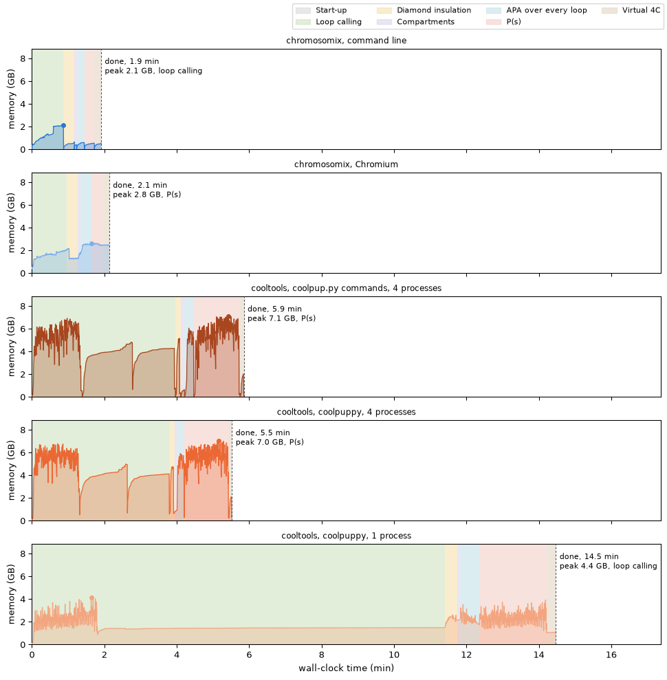

```python
def minutes(seconds):
    return f'{seconds / 60:.1f} min' if seconds >= 90 else f'{seconds:.0f} s'


#: Each phase's shade, and each side's colour, as the R figure has them (notebooks/scripts/timing.plot.R).
PHASE_COLOURS = {'start-up': '#d9d9d9', 'loops': '#cfe3c1', 'insulation': '#f5e2ad', 'compartments': '#dcd2ec',
                 'apa': '#c6e2ea', 'ps': '#f4cfc7', 'fourc': '#e4d6c3'}
SIDE_COLOURS = {'chromosomix': APP_COLOUR, 'chromium': '#7fb0ea', 'reference-1': '#f3a57f', 'reference': REF,
                'reference-cli': '#a8461f'}
first_run = steps[steps['run'] == 1]
traced_run = weighed[weighed['run'] == 1]
ENDS = {side: first_run.loc[(first_run['side'] == side) & (first_run['step'] == 'total'), 'to_s'].iloc[0] / 60
        for side in P_SIDES}
TOP = traced_run['mb'].max() / 1024 * 1.25
fig, axes = plt.subplots(len(P_SIDES), 1, figsize=(10, 1.2 + 1.8 * len(P_SIDES)), sharex=True, sharey=True,
                         layout='constrained')
for ax, side in zip(axes, P_SIDES):
    colour = SIDE_COLOURS[side]
    phases = first_run[(first_run['side'] == side) & first_run['step'].isin(PHASE_COLOURS)].dropna(subset=['from_s'])
    for one in phases.itertuples():
        ax.axvspan(one.from_s / 60, one.to_s / 60, color=PHASE_COLOURS[one.step], alpha=0.6, lw=0, zorder=0)
    points = traced_run[traced_run['side'] == side].sort_values('seconds')
    x, gb = points['seconds'].to_numpy() / 60, points['mb'].to_numpy() / 1024
    ax.fill_between(x, gb, color=colour, alpha=0.3, lw=0, zorder=2)
    ax.plot(x, gb, color=colour, lw=1, zorder=3)
    # Where the weighings peak, and the peak as the table gives it: never less than the largest resident set
    # any one process reached, which a weighing can miss.
    peak = points.loc[points['mb'].idxmax()]
    most = first_run.loc[(first_run['side'] == side) & (first_run['step'] == 'total'), 'peak_mb'].iloc[0]
    name = PIPELINE_TASKS[peak['step']][0]
    ax.scatter([peak['seconds'] / 60], [peak['mb'] / 1024], s=18, color=colour, zorder=4)
    # Where it finished and the most it held, on two lines just past its end, where nothing is drawn: on a side
    # of two minutes, its own phases have no room for them.
    ax.axvline(ENDS[side], color=INK2, lw=0.8, ls=(0, (3, 2)), zorder=4)
    ax.annotate(f"done, {minutes(ENDS[side] * 60)}\npeak {most / 1024:.1f} GB, {in_a_sentence(name)}",
                (ENDS[side], TOP * 0.92), xytext=(4, 0), textcoords='offset points', fontsize=8, va='top')
    ax.set_title(P_SIDE_LABELS[side], fontsize=9)
    ax.set(ylabel='memory (GB)', ylim=(0, TOP), xlim=(0, max(ENDS.values()) * 1.2))
    ax.grid(False)
axes[-1].set_xlabel('wall-clock time (min)')
handles = [plt.Rectangle((0, 0), 1, 1, color=c, alpha=0.6) for c in PHASE_COLOURS.values()]
fig.legend(handles, [PIPELINE_TASKS[step][0] for step in PHASE_COLOURS], loc='outside upper right',
           ncols=4, fontsize=8)
plt.show()
```

```python
def p_value(step, side, column):
    return float(steps.loc[(steps['step'] == step) & (steps['side'] == side), column].mean())


P_TEXT = {'app': minutes(p_value('total', 'chromosomix', 'wall_s')),
          'ref': minutes(p_value('total', 'reference', 'wall_s')),
          'wall': f"{p_value('total', 'reference', 'wall_s') / p_value('total', 'chromosomix', 'wall_s'):.1f}",
          'cpu': f"{p_value('total', 'reference', 'cpu_s') / p_value('total', 'chromosomix', 'cpu_s'):.1f}",
          'app_peak': f"{steps.loc[steps['side'] == 'chromosomix', 'peak_mb'].max() / 1024:.1f} GB",
          'ref_peak': f"{steps.loc[steps['side'] == 'reference', 'peak_mb'].max() / 1024:.1f} GB",
          'app_start': f"{p_value('start-up', 'chromosomix', 'wall_s'):.2f} s",
          'ref_start': f"{p_value('start-up', 'reference', 'wall_s'):.1f} s",
          'loops': f"{p_value('loops', 'reference', 'wall_s') / p_value('loops', 'chromosomix', 'wall_s'):.1f}"}


def against(step):
    """A step of chromosomix's against the script's: × on the wall clock and × in CPU time, above 1 faster."""
    name = PIPELINE_TASKS[step][0]
    return (f"{in_a_sentence(name)}, "
            f"{p_value(step, 'reference', 'wall_s') / p_value(step, 'chromosomix', 'wall_s'):.1f}× on the wall clock "
            f"and {p_value(step, 'reference', 'cpu_s') / p_value(step, 'chromosomix', 'cpu_s'):.1f}× in CPU time")


P_SLOWER = [step for step in PIPELINE_STEPS if p_value(step, 'chromosomix', 'wall_s') > p_value(step, 'reference', 'wall_s')]
P_TEXT['slower'] = ('In none of the six is chromosomix slower on the wall clock.' if not P_SLOWER else
                    'On one thread against the script\'s processes, chromosomix is slower on the wall clock at '
                    + '; '.join(against(step) for step in P_SLOWER) + '.')
# The two other sides, where they ran: the app in Chromium, and the script on one process.
P_TEXT['browser'] = '' if 'chromium' not in P_SIDES else (
    f"In Chromium the app takes {minutes(p_value('total', 'chromium', 'wall_s'))}, its opening of the map "
    f"({minutes(p_value('start-up', 'chromium', 'wall_s'))}) among it, and its page's processes hold at most "
    f"{steps.loc[steps['side'] == 'chromium', 'peak_mb'].max() / 1024:.1f} GB.")
P_TEXT['one'] = '' if 'reference-1' not in P_SIDES else (
    f"On one process, as chromosomix computes, the script takes {minutes(p_value('total', 'reference-1', 'wall_s'))}: "
    f"{p_value('total', 'reference-1', 'wall_s') / p_value('total', 'chromosomix', 'wall_s'):.1f} times "
    f"chromosomix's time on the command line, and "
    f"{p_value('total', 'reference-1', 'wall_s') / p_value('total', 'reference', 'wall_s'):.1f} times its own on "
    f"{P_THREADS}.")
# And the reference's own command lines, on as many processes as the script.
P_TEXT['cli'] = (
    f"Run as their own commands, one after another as chromosomix's are, cooltools and coolpup.py take "
    f"{minutes(p_value('total', 'reference-cli', 'wall_s'))}: "
    f"{p_value('total', 'reference-cli', 'wall_s') / p_value('total', 'chromosomix', 'wall_s'):.1f} times "
    f"chromosomix's time, each command paying its own start-up and reading the map again, and the loops handed "
    f"to the pileup through a file.")
```

*Rendered in 33 min 4 s, from 6 November 2026, 08:55 UTC to 09:28 UTC, by chromosomix 0.21.0 at `f2ac3bb1`.* This render, as JSON.